# Advances in crop insect modelling methods—Towards a whole system approach - ScienceDirect

## Figures (7)

[figure not shown]

## Tables (1)

1. Table 1

## [Ecological Modelling](https://www.sciencedirect.com/journal/ecological-modelling)

[Volume 354](https://www.sciencedirect.com/journal/ecological-modelling/vol/354/suppl/C), 24 June 2017, Pages 88-103

# Review Advances in crop insect modelling methods—Towards a whole system approach

Under a Creative Commons [license](https://creativecommons.org/licenses/by-nc-nd/4.0/)

Open access

## Highlights

**•**

How can pest population dynamics be predicted in the presence of multiple factors?

**•**

How do biotic and [abiotic factors](https://www.sciencedirect.com/topics/earth-and-planetary-sciences/abiotic-factor) affect the interactions between pests and their natural enemies?

**•**

How can area-wide impacts of natural enemies on pest populations be measured and predicted?

**•**

How can we best describe the spreading patterns of pests and assess the risk of invasion to other areas?

**•**

[Insect pests](https://www.sciencedirect.com/topics/agricultural-and-biological-sciences/insect-pests) adapt to climatic change and survive in new environmental conditions and control pressures. Can we develop models to account for and predict these changes?

## Abstract

A wide range of insects affect crop production and cause considerable yield losses. Difficulties reside on the development and adaptation of adequate strategies to predict insect pests for their timely management to ensure enhanced agricultural production. Several conceptual modelling frameworks have been proposed, and the choice of an approach depends largely on the objective of the model and the availability of data. This paper presents a summary of decades of advances in insect population dynamics, phenology models, distribution and risk mapping. Existing challenges on the modelling of insects are listed; followed by innovations in the field. New approaches include artificial neural networks, cellular automata (CA) coupled with fuzzy logic (FL), fractal, multi-fractal, percolation, synchronization and individual/agent-based approaches. A concept for assessing climate change impacts and providing adaptation options for agricultural pest management independently of the United Nations Intergovernmental Panel on Climate Change (IPCC) emission scenarios is suggested. A framework for estimating losses and optimizing yields within crop production system is proposed and a summary on modelling the economic impact of pests control is presented. The assessment shows that the majority of known insect modelling approaches are not holistic; they only concentrate on a single component of the system, i.e. the pest, rather than the whole crop production system. We suggest system thinking as a possible approach for linking crop, pest, and environmental conditions to provide a more comprehensive assessment of agricultural crop production.

## Keywords

Insect modelling approaches

Integrated pest management

Crop production

Climate change

Impact assessment

Yield losses

System thinking

## 1. Introduction

Crop production schemes can be considered as complex systems with multiple interacting processes consisting of several subsystems (particularly crop growth and insects crop interactions in this context) and components, each having their own unique characteristics and behaviour while contributing to the overall arrangement and function of the complete system (Wallach et al., 2013, Fath, 2014, Walters et al., 2016). In crop production systems, many components interact simultaneously in a highly nonlinear nature (Wallach et al., 2013, Walters et al., 2016). These interactions and nonlinearities need to be taken into account when attempts are made to understand or predict the system behaviour. Understanding, managing and forecasting the impacts of pests in crop production, therefore, are challenging (Garrett et al., 2013). Although modelling efforts focusing on [insect pests](https://www.sciencedirect.com/topics/agricultural-and-biological-sciences/insect-pests) and their interactions with plants, weather, nitrogen, water control, supply, demand and others factors (Gutierrez et al., 1988, Gutierrez et al., 1991, Bawden, 1991, Van Ittersum et al., 2003) exists; still studies that include the full range of interactions among system components are limited (Wallach et al., 2013, Walters et al., 2016). Additionally, pest simulation models commonly simulate the dynamics of single insect as the host and physical environment affect it. A holistic view is supported in which systems management is predicated on the admission that overall system behaviour will be influenced by changes in any system component (Wallach et al., 2013, Walters et al., 2016). While models are useful tools for synthesizing information and hypotheses, their application must be in the context of the system to be managed. Implicit in the latter is determination of the ecological and socio-economic characteristics within which the model, its outputs or a simplified version of the model, must operate to assist in decision-making for pest management. The recent publication by Walters et al. (2016) applied system dynamics modelling to explore ways of using sustainable practices in agriculture production. It is suggested that complete models that include biological, ecological, economical and social processes and their interactions can provide considerable insight into the behaviour of crop production and guide on the ways of managing the system with the aim of sustainably increasing productivity (Walters et al., 2016).

This paper highlights some important research questions that stimulated the development of methods and tools for [agricultural pest](https://www.sciencedirect.com/topics/earth-and-planetary-sciences/agricultural-pest) modelling. A summary of the most common concepts, tools, methods techniques are given. A list of some challenges is specified with possible new directions that consider system-thinking approach as a prospect for including pest impacts in crop models is also provided.

The approaches, methods and tools for pest modelling developed and used during the last decade focused on answering a number of relevant questions that arose while conducting research activities. Indeed, models are useful in answering relevant questions such as:

**a**

How can pest population dynamics be predicted in the presence of multiple factors?

**b**

How do biotic and [abiotic factors](https://www.sciencedirect.com/topics/earth-and-planetary-sciences/abiotic-factor) affect the interactions between pests and their natural enemies?

**c**

How can area-wide impacts of natural enemies on pest populations be measured and predicted?

**d**

How can we best describe the spreading patterns of pests and assess the risk of invasion to other areas?

**e**

Insect pests adapt to climatic change and survive in new environmental conditions and control pressures. Can we develop models to account for and predict these changes?

## 2. Modelling insect pest populations growth and dynamics

To answer questions 1 and 2, matrix models, phenology models and differential equations have been used as described below.

### 2.1. Matrix models

Over several decades, for describing the changes that occur on the population densities of insects in a region, matrix models have been widely used (Leslie, 1945, Lefkovitch, 1965, Lewis, 1977). When using this method for insects, the age structure of the population was described in a matrix with one single column with the number of females (Lewis, 1977). Over time the approach evolved to include other factors such as temperature (Choi and Ryoo, 2003) and age width. The notion of probability for changing stage group at each time interval was included and later contributed in creating into the model a distribution of times flow through stages (Choi and Ryoo, 2003)

### 2.2. Phenology models

Several authors have shown that the [physiological response](https://www.sciencedirect.com/topics/earth-and-planetary-sciences/physiological-response) of most poikilothermic species is adapted to a particular temperature range, which is often considered as an [abiotic factor](https://www.sciencedirect.com/topics/earth-and-planetary-sciences/abiotic-factor) influencing the species abundance and establishment in a region (Briere et al., 1999, Fand et al., 2014a, Fand et al., 2014b). Using the optimum temperature concept, life table data of species are obtained at constant temperatures in the laboratory. Through a step-by-step approach, mathematical functions for development time, development rate, mortality, senescence, survival and reproduction of the species were established and combined to yield the specieś phenology model. To illustrate, their application phenology models were developed for noctuid lepidopteran [stem borers](https://www.sciencedirect.com/topics/earth-and-planetary-sciences/stem-borer), *[Busseola fusca](https://www.sciencedirect.com/topics/agricultural-and-biological-sciences/busseola-fusca)* (Fuller) and *[Sesamia calamistis](https://www.sciencedirect.com/topics/agricultural-and-biological-sciences/sesamia-calamistis)* Hampson (Khadioli et al., 2014). These models assisted in estimating the lower and upper temperature threshold for survival of the insects. In addition, phenology models can be simulated either in a deterministic or stochastic manner to yield the following life table parameters of the species: intrinsic rate of natural population increase (*r<sub>m</sub>*), net reproduction rate (*R<sub>0</sub>*), finite rate of increase (*ƛ*), mean generation time (*G*), and the doubling time (*t*) (Khadioli et al., 2014). These parameters are crucial in population studies. For instance, *r<sub>m</sub>* helps to estimate the rapidity of a species population increase when occupying a new environment (Messenger, 1964) and *R<sub>0</sub>* is often applied to estimate the ability of a population to colonize a new area with *R<sub>0</sub>* *<* *1*.*0* indicating a negative or declining population growth (Pilkington and Hoddle, 2006, Fand et al., 2014a, Fand et al., 2014b).

Success of [insect pest](https://www.sciencedirect.com/topics/agricultural-and-biological-sciences/insect-pests) management actions largely depends on the efficacy of the management action, the life stage of the pest targeted and the timing of the intervention (Wilby and Thomas, 2002, Mills and Getz, 1996). For example, the efficient releases of natural enemies or application of any control measure to reduce the population density of an insect pest need to coincide with high presence of the most susceptible life stage of the species in the field (Wilby and Thomas, 2002, Sporleder et al., 2013). Similarly, in pest control programmes, targeting the life stage of a pest most efficient to destroy the plant is critical for success (Diuk-Wasser et al., 2010). In this respect, simulation of phenology model with a stage structure approach in a region over specified periods, could provide details on the proportion of individual life stages of the species (Sporleder et al., 2013).

### 2.3. Differential equations

Several differential equations in continuous and discrete forms are used to explain empirical datasets for single [species pest](https://www.sciencedirect.com/topics/earth-and-planetary-sciences/pest-species) population fluctuations over time (Nedorezov et al., 2008, Tonnang et al., 2009). The study of population dynamics focuses on model parameter estimation, comparison with empirical results and evaluation of system steady states (Nakanishi and Cooper, 1974, Gutierrez et al., 1991, Tonnang et al., 2009). These models are also employed to determine the likelihood of success of [classical biological control](https://www.sciencedirect.com/topics/agricultural-and-biological-sciences/classical-biological-control) programmes; thus, interaction between pest species (host) and its natural enemy (parasitoid) (Barratt et al., 2010). For instance, how the Lotka-Volterra equation (Filho et al., 2005) was fitted to population density data of the [diamondback moth](https://www.sciencedirect.com/topics/agricultural-and-biological-sciences/diamondback-moth) (DBM), *Plutella xylostella* (L.) (Hellen), to predict the per plant abundance of the pest on cabbage over time (Tonnang et al., 2009) (Fig. 1). The study revealed a satisfactory fit of the model to field data and suggested the possibility of using the Lotka-Volterra equation to mimic the behaviour of insect populations (Tonnang et al., 2009).

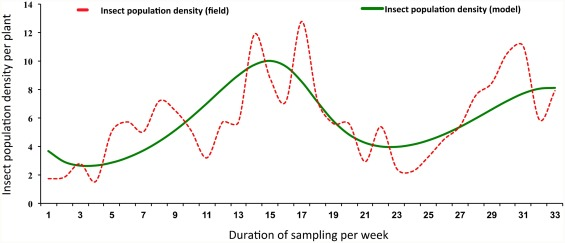

Fig. 1. Thirty-three (33) weeks field sampling of population density of an insect (diamondback moth) per plant of cabbage and predictions of the same using Lotka–Volterra model.

(adapted from Tonnang et al. (2009)).

### 2.4. Competition model

Systems of differential equations are developed to explore the effects of resource (crop) and competition between insect pest species (Kaplan and Denno, 2007). With the application of stability theory and qualitative analyses, numerical simulations are performed around the axial, planar and interior equilibrium points to understand the interactions between one, two or more species competing for a single resource. Results show that if a single species interacts with a resource, the species could establish and sustain a stable population density. However, if two or more species are competing for the same resource, the combinations of three parameters (half-saturation, growth rate, and mortality rate) determine which species outcompetes the other (Mwalusepo et al., 2014). In other words, a species with a high affinity for the resource can still loose the competition if it has a low growth and high mortality rate. These results demonstrate that one competing species could displace another one, independently of the initial size of its population. This means that at equilibrium points and in a habitat with a single limiting resource the best competitor is the species that has the lowest equilibrium resource value (Desharnais et al., 2001, Mwalusepo et al., 2014).

### 2.5. Fitting models

In fitting models, gradient matching method or the development of a loss function that uses the difference between predictions of the model equations and empirical time-series of the population density obtained from field surveys is usually derived (Ellner et al., 2002). To test the model [goodness of fit](https://www.sciencedirect.com/topics/earth-and-planetary-sciences/goodness-of-fit) in capturing field data, the behaviour of residuals between experimental values and theoretical trajectories are examined using criteria such as the Durbin–Watson (Nedorezov et al., 2008) and the resulting sign series subjected to a test of randomness of distribution (Swed and Eisenhart, 1943). From the analyses, results are often presented in form of the model fit or did not fit the insect species experimental trajectories and suggestions are made such as the inclusion of abiotic factors to improve the model prediction.

## 3. Modelling insects to identify areas of pest invasion risk and management priority

[Species distribution models](https://www.sciencedirect.com/topics/earth-and-planetary-sciences/environmental-niche-modeling) (SDMs) are used to measure and predict area-wide impacts of natural enemies on pest populations, to describe the spreading patterns of pests and to assess the risk of invasion to other areas (Questions 3–4), (Elith and Leathwick, 2009, Huntley et al., 2004, Guisan and Thuiller, 2005). These models help to predict distributions across landscapes and to gain ecological and evolutionary insights. The predictions can also be used for the identification of areas where an insect species is likely to be found (Fiaboe et al., 2006). The outputs of SDMs, risk maps, are presented as communication tools to inform specific hypotheses for controlled experiments or [observational studies](https://www.sciencedirect.com/topics/agricultural-and-biological-sciences/observational-studies) (Venette et al., 2010) or utilized in strategic pest management decisions such as restrictions on the importation of certain crops, implementation of quarantine measures and the design of pest surveys (Sporleder et al., 2013).

SDMs are broadly undertaken through adoption of an inductive or deductive approach (Venette et al., 2010). In the inductive approach, the presence of an organism in a location is related to the prevailing bio-climatic variable and the likelihood of the presence of the organism in other areas are predicted. This modelling technique follows a ‘top-down’ approach relying upon the identification of relationships between the recorded distribution of the target organism and environmental variables and used to predict distribution and/or abundance in an unmapped area of changed environmental conditions (Stokland et al., 2011). Algorithms and tools such as the Maximum Entropy (MaxEnt) and the Genetic Algorithm for Rule-set Prediction (GARP) utilize the inductive approach (Venette et al., 2010). The deductive approach starts by modelling the species response to environmental variables and applies the model for predicting environmental suitability of the organism. It is based on a ‘bottom-up’ technique, whereby direct measurements of the relationships between aspects of life-history (development, survival, productivity, *etc*.) and individual environmental variables are used to identify the environmental space where an organism’s persistence should be feasible (Khadioli et al., 2014, Kearney and Porter, 2009). Tools such as the Insect Life Cycle Modelling (ILCYM) software (Sporleder et al., 2013) utilise the deductive approach. The CLIMEX-compare location function and the North Carolina State University (NCSU) [Animal and Plant Health Inspection Service](https://www.sciencedirect.com/topics/agricultural-and-biological-sciences/animal-and-plant-health-inspection-service) (APHIS) [Plant Pest](https://www.sciencedirect.com/topics/agricultural-and-biological-sciences/plant-pests) Forecasting System NAPPFAST are based on a combination of inductive and deductive approaches. In all approaches, presence/absence data are added to environmental and biological variables to predict the likelihood for a location to be suitable for the occurrence/abundance of an organism (Sporleder et al., 2013).

### 3.1. Inductive approach

GARP is an ecological niche modelling method based on a genetic algorithm used to estimate the potential spatial distribution of organisms with dispersal capabilities (Stockwell, 1999). This approach was inspired by the evolutionary process of natural selection to obtain the most informative model from a series of possible solutions (Stockwell, 1999). Practically, GARP relates ecological characteristics of known occurrence points of a pest to randomly sampled points from the rest of the study region, seeking to develop a series of decision rules that best summarize factors associated with the presence. GARP was useful in guiding the site selection for natural enemy exploration of the invasive red spider mite *[Tetranychus evansi](https://www.sciencedirect.com/topics/agricultural-and-biological-sciences/tetranychus-evansi)* Baker and Pritchard, an important pest of tomato in East and southern Africa (Fiaboe et al., 2006). Together with pest occurrences data sets from Kenya and Zimbabwe, a GARP model was used to predict the native regions of *T. evansi* in South America. These regions have similar environmental conditions to areas in Africa where the mite has become a problem, and guided researchers in the search for natural enemies in the native regions of the pest (Fiaboe et al., 2006).

MaxEnt theory is founded on the estimation of the consideration that individuals occur in proportion to their population density. If the total population size is known, the model can predict the occurrence rate in a given cell, defined as the expected number of individuals in that cell (Cao et al., 2013). However, when the population size is unknown, only relative comparisons among the occurrence rates are meaningful, resulting in a relative occurrence rate (Cao et al., 2013, Hastie and Fithian, 2013). Assuming that an individual was observed in a specific location, the relative occurrence rate becomes the relative probability that the individual was derived from each cell in the landscape (Hastie and Fithian, 2013). Under these assumptions, MaxEnt inputs a list of organism presence locations and a set of environmental predictors (precipitation, temperature, *etc*.) across a landscape divided into grid cells and then extracts a sample of background locations, which are contrasted against the presence locations. The risk of spread of the invasive fruit fly *Bactrocera invadens* Drew, Tsuruta & White across Africa was investigated with MaxEnt (De Meyer et al., 2010, Biber-Freudenberger et al., 2016). It was found that [West Africa](https://www.sciencedirect.com/topics/earth-and-planetary-sciences/western-africa), Central Africa, Madagascar, and parts of East Africa, were predicted to have climatic conditions highly suitable for the pest establishment and persistence (De Meyer et al., 2010, Biber-Freudenberger et al., 2016).

### 3.2. Deductive approach

In the recent past, phenology models have been applied to estimate the potential distribution and to conduct risk assessments of pests in a spatially explicit way (Sporleder et al., 2013). The deductive model approach estimates the stage-specific development, survival and reproduction rates of the pests, from which risk indices like the establishment risk index (*EI*), generation index (*GI*) and activity index (*AI*) are derived to assess the potential distribution and abundance of the species (Fand et al., 2014a, Fand et al., 2014b). [Climatic factors](https://www.sciencedirect.com/topics/earth-and-planetary-sciences/climatic-factor) are used to establish the linkage between indices and landscape (Sporleder et al., 2013) from which distribution maps can be derived. The ILCYM software is a tool that assists in developing phenology models, conducts population analysis and risk mapping using this principle (Sporleder et al., 2013). Several phenology models for key pests of staple and cash crops and their natural enemies have been developed using ILCYM and applied for spatial predictions of regions of the pests occurrence and abundance (Fand et al., 2014a, Fand et al., 2014b, Mwalusepo et al., 2015).

### 3.3. Inductive and deductive approaches

The CLIMEX model theory is based on the estimated response of pests to temperature and moisture. The approach was developed under the assumption that, if it is known where an organism lives, the climatic conditions it tolerates can be inferred (Sutherst and Maywald, 1985, Sutherst, 2003) to predict other regions where the species can survive and reproduce. CLIMEX assumes that an organism at a given location experiences two seasons during a year, one with population growth and the other with population decline (Sutherst and Maywald, 1985, Sutherst, 2003). Overall, the model proposes that habitat suitability at a location for a given organism is provided by an Eco-climatic Index (*EI*), which combines the annual potential for population growth (*GI*), the annual stresses that limit survival during the unfavourable season (*SI*) and the interactions between stresses (*SX*) (Sutherst and Maywald, 1985). A study by Tonnang et al. (2015) using CLIMEX demonstrated that the potential of invasion of *[Tuta absoluta](https://www.sciencedirect.com/topics/agricultural-and-biological-sciences/tuta-absoluta)* (Meyrick) (Lepidoptera: Gelechiidae), a devastating pest of tomato, is very high in parts of Asia, the Middle East, New Zealand, the US and a large section of Australia.

### 3.4. Predicting the efficacy of a pest management strategy

Among the various insect pests control management strategies, fungal-based [biopesticides](https://www.sciencedirect.com/topics/earth-and-planetary-sciences/biopesticide) are considered to be quite effective, species specific and environmentally friendly (Auld, 2002). Target pests are killed only if the fungus ‘recognizes’ the insect as a suitable host and is able to germinate and penetrate the cuticle, which is then eventually resulting in death and development of mycosis on the host (Ekesi et al., 2002, Dimbi et al., 2009). With the enhanced efficacy achieved through selection of ecologically adapted fungi isolates and efficient formulations, efforts are being devoted to optimize the effectiveness of such biopesticides by integrating them within a novel modelling framework to enhance their performance in the field within the context of [integrated pest management](https://www.sciencedirect.com/topics/earth-and-planetary-sciences/integrated-pest-management) (IPM). In this regard, the effects of temperature on the virulence of the [entomopathogenic fungus](https://www.sciencedirect.com/topics/agricultural-and-biological-sciences/entomopathogenic-fungi) *[Metarhizium anisopliae](https://www.sciencedirect.com/topics/agricultural-and-biological-sciences/metarhizium-anisopliae)* to adults and second [instars](https://www.sciencedirect.com/topics/agricultural-and-biological-sciences/instar) of the [Western Flower Thrips](https://www.sciencedirect.com/topics/agricultural-and-biological-sciences/western-flower-thrips) *Frankliniella occidentalis* (Pergande) were assessed. Non-linear mathematical expressions such as Cubic and Lactin (Logan et al., 2006, Maiorano et al., 2012) were fitted to data of the virulence of *M. anisopliae* isolate ICIPE69 on *F. occidentalis* (Kuboka, 2013). Spatial simulations of the fungus efficacy for East Africa were undertaken using (daily) temperatures as outlined by Kroschel et al. (2013). A Lactin model provided a better fit for the efficacy of the fungus especially at lower temperatures and the [spatial mapping](https://www.sciencedirect.com/topics/earth-and-planetary-sciences/spatial-mapping) of the model indicated that the fungus could be effective in most mid and low-altitude regions of east Africa.

## 4. Modelling insects for decision making in the context of changing climate

This section provides answer to question 5 that stipulates, **“**Insect pests adapt to climatic change and survive in new environmental conditions and control pressures. Can we develop models to account for and predict these changes?”

### 4.1. Overview of climate change induced impacts on insects

Range shifts or changes of many insects may occur and new combinations of pests could emerge as natural ecosystems respond to altered temperature and precipitation profiles (Garrett et al., 2013). The increase in frequency and magnitude of extreme events (heat waves, heavy rainfall, storms *etc*.) can disrupt the synchrony between the growth, development and reproduction of [biological control agents](https://www.sciencedirect.com/topics/agricultural-and-biological-sciences/biological-control-agents) and their pest hosts/prey, leading to interferences in both natural and implemented biological (control) processes (Aurambout et al., 2009, Guisan et al., 2013). Within this context, assessment and forecasting of future shifts in the distribution of insects at local, regional and global scales are necessary to deploy pre-emptive mitigation strategies (Ehrlén and Morris, 2015). Can we develop models to account for, and predict these changes (question 5)?

### 4.2. Assessing climate change induced impacts on insects via models

The modelling approaches and tools presented above have been used to predict the distribution of insects under past, current and future climatic conditions by inferring the environmental requirements of the species from either laboratory experiments (ILCYM) or zones where they are currently known to occur (CLIMEX, MaxEnt and GARP). Based on these requirements, the insect geographic distributions are predicted and the results can be useful for land management and decision-making processes (Guisan et al., 2013). Analyses are often carried out using climate data under a certain climate change scenario obtained from global circulation models (GCM) (Ehrlén and Morris, 2015). Scenarios are generated based on a set of assumptions about drivers of future global emissions. These modelling exercises have revealed the likely impacts of climate change for some insect pest species (Fand et al., 2014a, Fand et al., 2014b, Tonnang et al., 2015, Biber-Freudenberger et al., 2016).

### 4.3. Challenges in modelling insect distributions

In pest population analyses, challenges always exist with regard to the rational of choosing one form of equation over another or when deciding to construct a new model for fitting observed datasets (Nedorezov et al., 2008, Tonnang et al., 2009). Paradoxically, obtaining good fit does not necessarily imply that the selected mathematical equation can clearly explain the type of dynamics and interactions between system components (Tonnang et al., 2009). Different equations may provide excellent and equal fit to observed data, while their mathematical characteristics yield different behaviour under the same environmental conditions. Another general problem is that there is no rule for finding the global minimum for the number of environmental variables that yields the best parameters of a fitted model. Instead, a variety of techniques have been developed and trial and error procedures are sometimes applied.

The modelling approaches of insects used to identify areas of priority and establish risk mapping have certain advantages and disadvantages (Table 1). They differ in the type of data required, complexity and nature of the estimated functions and to a certain extent, most likely depend on the specific species, in their predictive performance. Generally, the approach with dual features (inductive and deductive) seems to be more convincing and therefore preferable over either inductive or deductive approaches. One advantage is that it has the ability to simulate through laboratory manipulations the effects of new environmental extremes on the target species and to examine the existence of such thresholds and relationship changes, whereas inductive approach contribute to identify relationships within naturally observed limits (Venette et al., 2010, Sporleder et al., 2013). A constraint of inductive models is that they tend to link equilibrium distribution and/or abundance with the mean climatic conditions. In both modelling categories a considerable limitation is the impact of unexpected changes in the relationships between processes/distribution and any given environmental variable above or below thresholds that dwell outside currently observed limits. Models using the inductive approach present some merits as they are rapidly implemented and existing spatial datasets that are commonly accessible can be utilised (Venette et al., 2010).

Table 1. Advantages and disadvantages of commonly used tools, approaches and methods for pest and disease modelling.

| Approach | Advantages | Disadvantages |
| --- | --- | --- |
| GARP (Inductive) | Rule based Easy to implement Input commonly accessible datasets Accounts for relevant variables Provides statistical goodness of fit | Inferred relationships Links only the equilibrium points Input presence-only datasets Over estimates/underestimates distribution No phenology information |
| MaxEnt (Inductive) | Generates probability values Provides statistical goodness of fit. Performs well in data-poor situation Easy to extrapolate | Identifies relationships Input presence-only datasets No phenology information |
| ILCYM (Deductive) | Accounts for developmental thresholds Allows analysis of high resolution data Incorporates nonlinear relationships | Employs site/region specific parameters No occurrence data Only adapted for insects and disease vectors Accounts only for temperature |
| CLIMEX (Inductive and deductive) | Dual functionality Validates at continental level Establishes linear relationships | Difficult to input new datasets Difficult to fine-tune and calibrate Conducts analysis at a low resolution |

### 4.4. Limitations in assessing climate change induced impacts on insects

Other than the described drawbacks of modelling approaches used to assess climate change induced impact on insects have some drawbacks, the overall outcome of the assessment also suffers from the uncertainties involved in future climate modelling, where new biotic and abiotic interactions may affect currently established relationships with environmental variables (Hartley et al., 2006). Another crucial problem is the ambiguity for using a model developed for current distribution, which is then extrapolated in space and time to anticipate the pest/pests distributions under climate change (Hartley et al., 2006, Ehrlén and Morris, 2015). Future climate scenarios and derived distribution models have been criticized for being intrinsically unscientific, because they cannot be validated until the period of their projection has been reached (Garrett et al., 2013, Fand et al., 2014a, Fand et al., 2014b). Recent scientific focus in addressing this issue is on the promotion and advocacy for an ensemble modelling approach, which consists of identifying the ‘best’ model from an ensemble of scenarios of [GCMs](https://www.sciencedirect.com/topics/earth-and-planetary-sciences/general-circulation-model). In this context the best model is often judged to be the one which outputs match observed data as closely as possible (Araújo and New, 2007). In addition, no information is available on how species may respond under novel environments. Under these circumstances, it is argued that a new modelling framework is needed to limit uncertainties about future emissions of greenhouse gases and sulphate aerosols as well as uncertainties about the response of the climate system to these changes at global and local scales (Stott and Kettleborough, 2002).

The first Intergovernmental Panel of Climate Change (IPCC) guidelines (Carter, 1996) outline a process with seven steps for assessing the impacts of potential climate change and evaluating appropriate impacts that include the following: definition of the problem, selection of the methods, testing of the methods, selection of the scenarios, assessment of biophysical and socio-economic impacts of autonomous adjustments, and evaluation of adaptation strategies (Watson et al., 1998). However, the choice of a scenario and GCM, which directly contributes to suggestions of adaption options and decision-making, is full with a high level of uncertainty. A ‘wrong’ selection of a scenario or GCM can lead to very different recommendations. Additionally, results are impacted by further uncertainties such as: i) How much temperature change is likely to result from a given scenario of human-caused increases in greenhouse gas concentrations? ii) What will be the actual amounts of greenhouse gases added to the atmosphere in the future? iii) What will that do to local and regional climates?

## 5. Innovations on the methods and tools for modelling insects

As a means to overcome some of the challenges arising, researchers are gradually opting for the use and application of more robust, complex and [dynamical systems](https://www.sciencedirect.com/topics/earth-and-planetary-sciences/dynamical-system) based on advanced mathematics, computer and physics theories. These approaches include artificial [neural networks](https://www.sciencedirect.com/topics/agricultural-and-biological-sciences/neural-networks), [cellular automata](https://www.sciencedirect.com/topics/earth-and-planetary-sciences/cellular-automata) (CA) coupled with fuzzy logic (FL), fractal, multi-fractal, percolation, synchronization and individual/agent-based approaches (Bone et al., 2006, Smith and Conrey, 2007).

### 5.1. Artificial neural networks

Mathematical modelling using differential equations helps to gain understanding of the system dynamics, however, it is generally less accurate when used for population density prediction (Chon et al., 2000, Zhang and Zhang, 2008). The artificial neural network (ANN) approach is sometimes selected for predicting the potential population densities (Yang et al., 2009). ANN was for example used for population density predictions of [DBM](https://www.sciencedirect.com/topics/agricultural-and-biological-sciences/diamondback-moth) and its exotic ichneumonid parasitoid *[Diadegma semiclausum](https://www.sciencedirect.com/topics/agricultural-and-biological-sciences/diadegma-semiclausum)* Hellen (Tonnang et al., 2010) and to forecaste [paddy](https://www.sciencedirect.com/topics/agricultural-and-biological-sciences/paddies) [stem borer](https://www.sciencedirect.com/topics/earth-and-planetary-sciences/stem-borer) population occurrence (Yang et al., 2009). In this context, ANN was considered as a potent tool for predicting population densities with few assumptions on the field datasets. The approach allowed the use of data collected at any appropriate scale of the system, bypassing the assumptions and uncertainties that occurred when fitting differential equations to estimate parameters (Yang et al., 2009). ANN has further been suggested as a method to evaluate the relative effectiveness of natural enemies and to investigate augmentative biological control strategies (Zhang and Zhang, 2008, Tonnang et al., 2010).

### 5.2. Cellular automata (CA) coupled with fuzzy logic (FL)

Cellular automata (CA) models are implemented in spatially explicit, stage-structured cells governed by rules, which are created based on the biological and ecological of the pest data (Kari, 2005). This information can be derived from existing field and laboratory data on the [physiological responses](https://www.sciencedirect.com/topics/earth-and-planetary-sciences/physiological-response) to climate variables such as rainfall, temperature and humidity. Fuzzy logic (FL) is used to represent the degree of accuracy, also called truth-values, that is scaled between a probability threshold of 0 and 1 (Andriantiatsaholiniaina et al., 2004, Bone et al., 2006). This degree of truth is defined by an appropriate membership function that allows description of the convenient level of varying of intermediate state such as low, medium and high infestation level. In summary, instead of systematic manipulation of numerical data and fitting mathematical equations, this approach is implemented in form of computer codes in selected programming languages that improve flexibility for capturing level of pest damage on crop in a modelling structure (Bone et al., 2006, Guimapi et al., 2016). In a field situation, evaluation and quantification of pest complexity of spread, geometrical structure of how mobile organisms interact with their environment need to be included in the modelling framework, for instance to capture the damage caused by cereal stem borers to maize in Africa (Fig. 2). The development steps for the central cell of CA can be determined in three steps (Bone et al., 2006, Guimapi et al., 2016): i) Estimate the minimum radius of the neighbourhood (NH) then extract NH of CA by training data using an appropriate algorithm. For example, the data could represent environmental factors or presence/absence of stem tunnelling damages caused by the insect pest larvae and their moment of occurrence. In this case, the CA cell states will be binary (infested/non-infested). ii) With the knowledge of the stochastic behaviour of the oviposition and flight pattern of the insect, the spatial and temporal model for the oviposition process is developed. iii) Through fuzzy inference system, the information can be linked with the vague and imprecise knowledge of experts (IPM practitioners) about the degree of the contagion to spread given a degree of abundance of the pest or other relative datasets. Ten years of simulations (2008–2017) of CA rule based model calibrated with land vegetation cover, temperature, relative humidity and yield of tomato production were used to predict year-to-year, the risk of the invasion and spread of *T. absoluta* across Africa (Fig. 3). By inferring the pest natural ability to fly long distance revealed that *T. absoluta* could reach South Africa ten years after being detected in Spain (Guimapi et al., 2016). The Spatial and temporal spread of maize stem borer *[Busseola fusca](https://www.sciencedirect.com/topics/agricultural-and-biological-sciences/busseola-fusca)* (Fuller) (Lepidoptera: Noctuidae) damage in smallholder farms is reported in (Ndjomatchoua et al., 2016). By using the CA approach, the authors were able to determine the rule by which a plant gets infected by its neighbors, it was observed that if an uninfected plant is bordered by at least four infected plants, it is most likely to become damaged in the subsequent week (Ndjomatchoua et al., 2016).

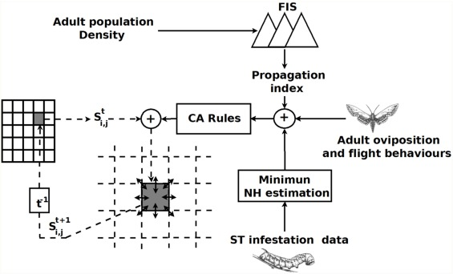

Fig. 2. Diagram summarizing an approach for modelling in the field situation the crop damages spread cause by phytophagous pest larvae. The approach is based on the combined application of [cellular automata](https://www.sciencedirect.com/topics/earth-and-planetary-sciences/cellular-automata) (CA) and fuzzy logic systems. The grid cells are abstractive representations of the plants inside a field. NH = neighbourhood, ST = stem tunnelling, FIS = fuzzy inference system, S = state, (i,j) = spatial coordinates.

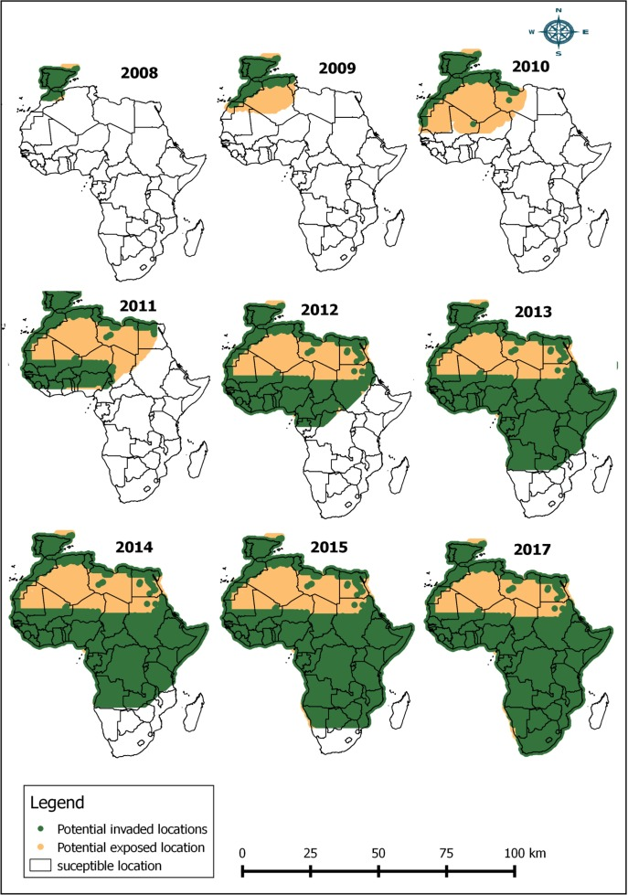

Fig. 3. The spread of *T. absoluta* in Africa obtained through a 10 years simulation of cellular automata rules based model considering vegetation, humidity, temperature and yield of tomatoes production as keys variables for the insect pest propagation. The areas in white are susceptible locations. Zones in brown are zone at low risk of invasion and spread of the pest. Zones in green represent zones at high risk of invasion and spread of the pest. (For interpretation of the references to colour in this figure legend, the reader is referred to the web version of this article.)

(adapted from (Guimapi et al. (2016)).

### 5.3. Fractal and multi-fractal

The term fractal is used to describe the self-similarity that appears in an object under varying degrees of magnification (Addison, 2002, Li, 2000, Jonckheere et al., 2006). With fractal analysis, the effect of possessing symmetry across scales with each small part of the object is capable of replicating the structure of the whole (Addison, 2002, Jonckheere et al., 2006). Although fractal method has been to characterize geometrically the occupancy of insect pest invasion in a complex landscape (Gamarra and He, 2008) and to analyse possible effects of fragmented agro-ecological landscapes in a successful biological control with natural enemies of insect (With et al., 2002); its single application only gives extensive description of the object, leading in practice to the application of multi-fractal dimensions. An object is multi-fractal if it has more than one fractal dimension (Jonckheere et al., 2006). Multi-fractal analysis can provide proper characterization of the spatial distribution of [pest infestations](https://www.sciencedirect.com/topics/earth-and-planetary-sciences/pest-infestation). For instance, it allows the application of information dimension (*Di*), which gives the degree of repartition of elements inside a surface and the correlation dimension (*Dc*) that provides the degree of localization of pest spread by measuring the level of clustering (Addison, 2002, Li, 2000, Jonckheere et al., 2006).

### 5.4. Percolation and cluster distribution

The phenomenon that evolves in time and space from randomly isolated patches in an area and becoming connected to form a giant cluster of the whole area is called percolation (Grimmett, 1999). By applying percolation theory, the spread of pests can be predicted (Wiens et al., 1997). The existence of a percolation threshold probability of invasion between plants can be used as followed: If the probability of colonizing a neighbouring plant is above this threshold the insect pest might spread invasively creating large patches, but below the threshold spreading is finite and restricted to comparatively small patches (Bailey et al., 2000). The prediction of invasive and non-invasive spread depends on constant colonization efficiency with time and percolation theory can elucidate how insect propagate and spread in a crop. With distributed lattices representing patches of pest damage, percolation theory can predict the threshold for transition between producing a small patch and the moment where the progression of a large patch will occur. Prior to the application of such a modelling framework, advance methods such as Kohonen neural network (Watts and Worner, 2009), K-means, Gaussian mixed and Moran’s indices for distributional cluster analysis are applied to increase the understanding of the patterns that exist in the datasets (Recknagel, 2001).

In Ndjomatchoua et al. (2016) an illustration of how multi-fractal method coupled with percolation can be used to analyse the spatial and temporal propagation of insect pests infestations in smallholder farms. The authors demonstrated that with a good knowledge and understanding of the biological and ecological processes that govern the infestation of maize farms by the African stem borer *Busola fusca* there is high probability to tract and predict the next plant to be damaged by the pest. Considering a cluster (Fig. 4) as a set of infested cells, which are totally isolated from one and others, the paper revealed that as the damages of the insect spread, the total number of clusters increases with time and start to decrease (percolation threshold) when the spatial expansion of completely isolated clusters is no more feasible. After the manifestation of the percolation threshold, the infested clusters connect and merge, resulting on the reduction of overal number of clusters. The marginal scale where the percolation was observed was cogitated as the spatial resolution threshold for the incidence of the percolation phenomenon (Ndjomatchoua et al., 2016).

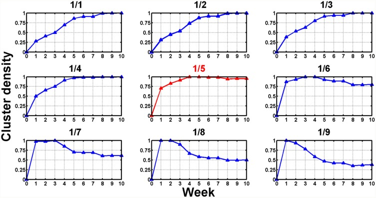

Fig. 4. Variation of the scale of observation of leaf damages propagation of *B. fusca* in a maize farm with time. The fraction on the top of each sub-figure represents the number of plants considered in each unit cell of the spatial grid during the observation. The scale *1/k* means that *k*-plants per unit cell were taken into consideration. The particular case 1/1 means that one plant is considered as one cell. It is assumed that if at least one plant among the *k* × *k* plants inside the cell is infected then the cell is considered as infected. For a fixed scale the corresponding total number of clusters (normalized between 0 and 1) is plotted as a function of the week of observation (Ndjomatchoua et al., 2016).

### 5.5. Synchronization

Synchronization is a process wherein many systems adjust a given property of their motion due to a suitable coupling configuration, or to an external forcing (Arenas et al., 2008). The occurrence of synchronization in large-scale coupled pest networks of is a fundamental phenomenon observed in nature (Arenas et al., 2008). In a tri-trophic system formed by a plant, an insect herbivore and its natural enemy (Pearse and Altermatt, 2013), each component has its own [biological rhythm](https://www.sciencedirect.com/topics/earth-and-planetary-sciences/rhythm-biology) and therefore can achieve rhythmic functional synchronization under defined natural conditions (Zhang et al., 2010). It was emphasised that correct application of synchronization processes in networked systems by integrating explicitly spatial and trophic couplings into current meta-population community approaches constitute a fundamental playground for deepening the understanding in pest dynamical behaviour (Thomas, 2001).

### 5.6. Agent based approach

The application of individual and agent-based approaches to study complex pest spreading dynamics if multiple hosts (animal, human and pathogen) are involved is an open field of research (Bonabeau, 2002). This modelling approach accounts for the physical contact patterns that result from movements of individuals (pests and hosts) between locations. An agent-based model is constructed by conceptualizing the structure of spatial and temporal dynamics of the transmission of the pest with theoretical analyses (as described in Fig. 2) and based on data on the biology and ecology of the pest including the dynamics, land use, and the interactions. The model outcome allows for the tracking and prediction of the spatio-temporal dynamics of a given insect pest in a specified environment (Grimm et al., 2005).

### 5.7. Role of remote sensing in crop insect pest assessments

Remote sensing can provide timely and spatially explicit data on the types and acreages of specific crops and growing periods, cropping system (e.g. intercropping or mono cropping), length of fallow period and within [field crop](https://www.sciencedirect.com/topics/agricultural-and-biological-sciences/field-crops) vitality variations (Forkuo and Maathuis, 2012). The within field variation can be a result of pests that affect crop leaf [pigments](https://www.sciencedirect.com/topics/agricultural-and-biological-sciences/photosynthetic-pigment) and water contents as well as leaf area index (LAI) (Ren et al., 2012). If scaling functions are developed, remotely sensed data sets could render spatially and temporally continuous observations of pest effects at regional scales. This is especially true for time-series variables, such as LAI or Land Surface Temperature (LST) that are known to be associated with pest habitat factors (Baret et al., 2007, Blum et al., 2015). Spatially explicit and area-wide information is much more effective than ‘point’ data, i.e. pest incidence or climate point measures. Just as many established crop models essentially rely on approximations to identify the possible location of crops in a particular study area (Thornton et al., 2009), there is an increasing trend to integrate climate and remotely sensed crop data to assess specific [climate change impacts](https://www.sciencedirect.com/topics/earth-and-planetary-sciences/climate-change-impact) on crop yields (Sultan et al., 2014). Field level spectral characteristics (or variable measures) of crop infections might, however, appear similar to other sources of crop stress and most often very high resolution and ‘hyperspectral’ data sets, which are presently still relative expensive, are needed to accurately map within-field pest infestation rates and to be able to separate crops from other land cover types (Baret et al., 2007). Currently there is a need to probe the feasibility of using newly available remotely sensed data sets and innovative data processing routines for accurate (explicit) crop mapping, including pest infestation and infection rates.

### 5.8. Theoretical framework for assessing climate change induced impacts on insects with no use of IPCC scenarios

The study on the effects of the elevation on the populations of the [olive fruit fly](https://www.sciencedirect.com/topics/agricultural-and-biological-sciences/olive-fruit-fly) *Bactrocera oleae* (Rossi) (Kounatidis et al., 2008) and the simulation of the pest (Petacchi et al., 2015) suggested that difference in the presence and abundance of insects in location can be influenced by altitude gradients. Motivated by these results and own experiences we hereby propose a theoretical conceptual framework for assessing climate change impacts and providing adaption options for crop insect pests with no application of IPCC scenarios. The modelling framework relies on the assumption that, although the climate is changing, all future local and regional climates already exist today and no complete novel climate with currently non-existing characteristics will be created in the future. If that is the case and considering the numerous uncertainties that also exist with the concept, development and implementation of impact models, it is suggested to conduct detailed and region specific analyses using information of different existing and well-known regional and local climates as input to impact models, to develop appropriate policy options and recommendations for the purpose of identifying adaptive responses. The approach will considerably reduce the uncertainties from IPCC scenarios currently used as input in different impacts assessment models and will provide the society with more accurate local/regional specific adaptive responses that can be used when necessary. Similar analyses can be conducted along altitudinal gradients, where a considerable change in [climatic factors](https://www.sciencedirect.com/topics/earth-and-planetary-sciences/climatic-factor) occur from low to high altitudes. A global database encompassing the results, outputs and outcomes of the assessments should be developed, documented and made available to communities with similar agro-ecological conditions and the world at large for future climate change adaption planning. An additional merit from this concept resides on the fact that the analyses will be conducted at a high spatial and temporal resolution, which enables capturing the insect pests potential establishment, distribution and abundance in a more accurate manner.

In a recent study on the impacts of climate change on insect pest population dynamics, two altitude gradient regions were targeted (Mwalusepo et al., 2015): 1) Taita Hills (Kenya) with elevation ranging from 700 to 2000 m.a.s.l.; latitude 3°25′S and longitude 38°20′E. The mean annual rainfall of the region is 500 mm (low altitude) and >1500 mm (upper mountain zone). The annual average temperature varies from 16.5 to 23.5 °C when shifting from low to high altitude. 2) In Tanzania, the selected area covers the south eastern slope of Mount Kilimanjaro from 700 to 1800 m.a.s.l., and is located between latitude 3°4′S and longitude 37°4′. Mean annual temperature varies from 18 to 23.6 °C and the average annual rainfall ranges from 1000 to 1300 mm. Both sites showed considerable variation in altitude gradients with graded climate characteristics (rainfall and temperature) as surrogates for changes in climate. Deep understanding on the mechanism the insects used to adapt in the transects provides valuable information, which can be harnessed into pest risk analyses procedures to formulate environmentally viable and localized pests control measures for different climate variables context for today and the future (Fig. 5).

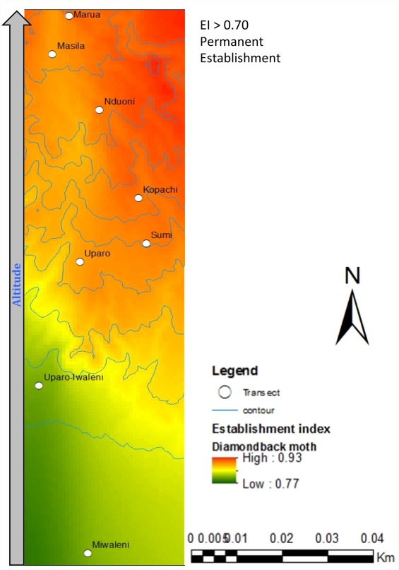

Fig. 5. High spatial and temporal resolution map for the potential establishment of Diamond-back moth (Plutella xylostella), a major insects pest of crucifer crops worldwide along altitude gradient of Mount Kilimanjaro. The predictions were made using the *Index interpolator module* of the Insect Life Cycle Modelling (ILCYM) Software as described in Mwalusepo et al. (2015). From the theory of ILCYM, an establishment index >0.7 means the insect can survive permanently in the area.

## 6. Modelling the economic impact of insect pests control

Impact evaluation of insect pest control determines the welfare changes from a given intervention on individuals and households and whether those changes are attributable to the intervention (Shelton et al., 2002). These evaluations can be made ex-ante or ex-post. The ex-ante approach evaluates the impact of future interventions providing information on the likely socio-economic and environmental impacts and how the flow of costs and benefits is distributed among the affected population. Ex-post impact assessments evaluate the impact of past interventions, measuring the benefits and the costs of the interventions and providing information on the pathways through which observed impacts have occurred. We describe here the common methods used for the economic impact modelling of crop insect pests.

### 6.1. Economic surplus approaches

The economic surplus approach stems from partial equilibrium framework, which is the most common approach for the evaluation of technological progress in agriculture (Alston et al., 1995). The model consists of estimating the aggregate total monetary benefits for producers and consumers entailed by the introduction of development interventions in a targeted social environment (Maredia et al., 2000). The approach has been used for the impact of the biological control of the cassava mealybug in Africa (Norgaard, 1988). In Benin, it has been used for the biological control program of mango mealybug (Bokonon-Ganta et al., 2002) and [water hyacinth](https://www.sciencedirect.com/topics/earth-and-planetary-sciences/water-hyacinth) (De Groote et al., 2003). The welfare benefits are compared to the monetary investments in order to appreciate the efficiency of interventions through the measure of the return to investment (Soul-kifouly et al., 2016). Economic benefits of interventions are extended to the estimation and analysis of the Net Present Value (NVP), the Internal Rate of Return (IRR) and Benefit-Cost Ratio (B/C) (Zeddies et al., 2001).

### 6.2. Computable general equilibrium (CGE) models

Unlike the economic surplus model that is a partial equilibrium model holding on only one market, CGE models capture the full economy, showing the many relationships between different actors and commodities. CGEs have been built to simulate the economic and social impacts of a wide range of scenarios including changes in the domestic economic such as technological change in agriculture (De Janvry et al., 2000). Elbehri and Macdonald (2004) applied the CGE model to estimate the potential impact of transgenic Bt-cotton in West and Central Africa.

### 6.3. Econometric approaches

The econometric estimate of the impact of insect pest management interventions captures the marginal effect on the output indicator of the intervention period (Masters, 1995). The appropriate counterfactual is most usually defined with reference to a control group, which has to be identified in a way that avoids selection bias and therefore the use of either experimental or quasi-experimental approaches (Muriithi et al., 2016).

#### 6.3.1. Average treatment effect (ATE) based methods

Assuming a farmer has adopted a pest control technology, the impact of the protection strategy is the difference between the actual outcome *Y<sub>1</sub>* and the outcome if it was not adopted *Y<sub>0</sub>*. The estimation of this impact at the individual level (*Y<sub>1</sub>* − *Y<sub>0</sub>*) became incalculable because of the impossibility of observing *Y<sub>0</sub>*. As solution, the quantity to be estimated is the average treatment effect (ATE = E [*Y<sub>1</sub>* − *Y<sub>0</sub>*]) (Imbens and Wooldridge, 2008). The ATE methods stem from the search for a solution to the absence of the counterfactual also referred to as missing data problem. The method used the Propensity-Score Matching (PSM) approach that can justifiably claim to be the solution to this problem, and thus to be the observational equivalent of a randomized experiment. Two groups are identified: households that have the treatment (denoted *D<sub>i</sub>* = 1 for household *i*) and those that do not (*D<sub>i</sub>* = 0). Treated units are matched to non-treated units on the basis of the propensity score. Several methods are used in the computation of the ATE, which represent the real impact estimates. Nazli (2010) used different matching methods including radius, kernel, stratification and covariate matching to assess the impact of the Bt-cotton on pesticide expenditure, cost of production, productivity, profit, income and poverty in Pakistan. A recent study by Sanglestsawai et al. (2015) assessed the impact of the participation in IPM Farmers’ Field Schools (FFS) in the Philippines.

#### 6.3.2. Instrumental variable based methods (IV)

The IV-based methods are used in impact assessment when there is endogeneity in the placement of the pest management programs. This means that programs are placed deliberately in areas with observed or not observed characteristics that are correlated with outcomes of interest in the assessment (Khandker et al., 2010). The IV approach aims at cleaning up this correlation between the participation in the program and the unobserved characteristics. The IV aims to clean up this correlation between the participation in the program and the unobserved characteristics. The common method used is the two-stage least square approach (2SLS). In assessing the impact of an IPM program on groundnut productivity in Ghana, Carlberg et al. (2012) used the 2SLS method to account for sampling selection and endogeneity of the program. Rejesus et al. (2009) examined the impact of disseminating information on IPM in terms of insecticide use and efficiency using IV approach that controls for endogeneity and selection bias.

#### 6.3.3. Difference in difference method (DD)

This method is applied to non-experimental evaluations. It compares treatment and comparison groups in terms of outcome changes over time relative to the outcomes observed for a pre-intervention baseline. The DD approach is a powerful way to eliminate the bias caused by the unobserved time constant variables in estimating impacts. It was used in FFS and Bt-cotton in China and has also be applied to assess the economic impact of IPM technologies for the control of mango fruit flies in Kenya (Kibira, 2015).

## 7. Towards the inclusion of insect pest impacts in yield losses into crop model

Proper estimations of actual crop yield with the help of models require detailed quantitative and knowledge of different levels of interactions between pest and crop. Because of the complexity of such a system, most crop growth models do not include routines for the simulation of damage caused by pests. In a simplified manner, the potential impacts of pests on crop yield loss or environmental damage over a forecast horizon could be accounted for using a two-step modelling tactics. First, pest models/tools are independently run and their outputs are used to define rules that can be included into crop models. These measurements can be translated to an indicator of potential damage due to pest. Second, within crop models, modules using a rule-based approach capable of connecting all compartments of the crop model such as FL system should be developed. With this reasoning the [effects of climate change](https://www.sciencedirect.com/topics/earth-and-planetary-sciences/climate-change-impact) on pest behaviour, flight time and synchronisation with the crop, virus acquisition and transmission rates, phenology changes and physiological responses can easily be incorporated. As an illustration, a detailed flow diagram, linking e.g. the maize plant model to stem borers (pest) damage using FL system is given (Fig. 6). The approach for incorporating pest damage into crop models has the potential for extending the practical applications of crop models to a broad range of problems that will necessitate a multidisciplinary approach and should involve greater cooperation among biologists, economists, [ecologists](https://www.sciencedirect.com/topics/agricultural-and-biological-sciences/ecologist), social scientists, and decision makers. As a way forward to address this problem of including pest impacts into crop models we propose a system-thinking modelling approach.

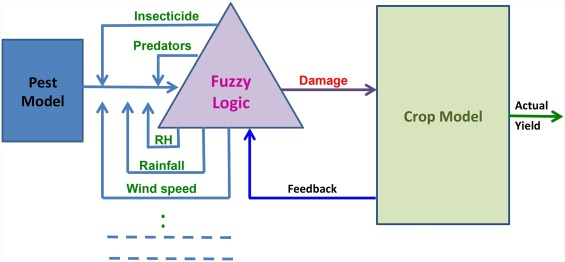

Fig. 6. Flow diagram, linking crop model to pest damage by fuzzy logic (FL) system. With its rules based approach, multi-trophic interactions and feedbacks are included into the crop model for direct estimate of the actual yield.

## 8. System thinking approach – prospect for including pest impacts into crop production

Understanding crop growth and predicting actual crop yield, requires the grasping of concepts such as the [food production](https://www.sciencedirect.com/topics/earth-and-planetary-sciences/food-production) systems, the multi-trophic interactions, the crop-pest systems, the ecosystem functions and processes, the socio-economic and socio-ecological challenges as well as respective feedbacks loops, biophysical flows, time delays, and nonlinearity within functional fluctuating bounds. Most of insect pest modelling approaches described earlier are not holistic because they concentrate on single components of the system rather than on the whole. In doing so, they miss the crucial interactions between the components. Thus they are failing to recognize that the performance of one part may have consequences elsewhere that are damaging for the whole. This fault is known as ‘sub-optimization’ (Jones et al., 1998). However, managing complex and unpredictable variables in agricultural ecosystems is similar to that for other systems, including the human body and social systems. The key weakness with currently used approaches is central to our operating philosophy in science to divide things into specialized parts for studying, known as reductionism (Jackson, 2003). In reality components of agricultural ecosystems interact, and, through a set of feedback loops, maintain ‘balance’ within functional fluctuating bounds. Moreover, therapeutic interventions into these systems might ameliorate symptoms for a time but counter-movement on the long term will neutralize their effectiveness. To illustrate, in production systems such as cocoa agroforestry systems, composed of several interacting sub-systems and components (cocoa, associated crops, non-crop plants, pests/diseases, beneficial insects and farmers) a pest management strategy targeting one pest could results in the removal of natural enemies which regulate or controlled another [pest species](https://www.sciencedirect.com/topics/earth-and-planetary-sciences/pest-species) (e.g. the simple presence of a parasitoid can cause ants to remain inside their nest and disrupt their protective effect on [hemipteran](https://www.sciencedirect.com/topics/agricultural-and-biological-sciences/homoptera) mutualists). Therefore considering cocoa plants as active components of multitrophic level interactions is crucial to a systems approach to pest management (Tscharntke et al., 2011). Management practices addressing one component or sub-system directly or indirectly affects the other components or the balance of the local ecosystem (Tscharntke et al., 2012). In these systems, plant traits may have important impacts on both herbivores and their natural enemies (Perfecto and Vandermeer, 2008, Anderson et al., 2009). Such mediated indirect interactions between herbivores may have a larger impact on biodiversity conservation and community structure than direct competition between herbivores (Wielgoss et al., 2012). Current advances in tritrophic level interactions among plants, crops, non-crops, herbivores and beneficial insects (parasitoids and predators) substantiate strong interconnections between these components and the importance of multitrophic perspectives as well as respective feedback loops (Fig. 7). Long-term resolutions for a system approach in pest management can only be achieved by restructuring and managing these systems in ways that maximize the array of fundamental ‘built-in’ ecosystem preventive strengths, with therapeutic tactics (e.g. the use of pesticides) serving strictly as backups to the natural regulators (Fig. 7). System thinking approach to pest management stresses holism, utilizing agroecological principles but translating them into a socio-economic and policy framework that stresses human resource development (Fig. 7).

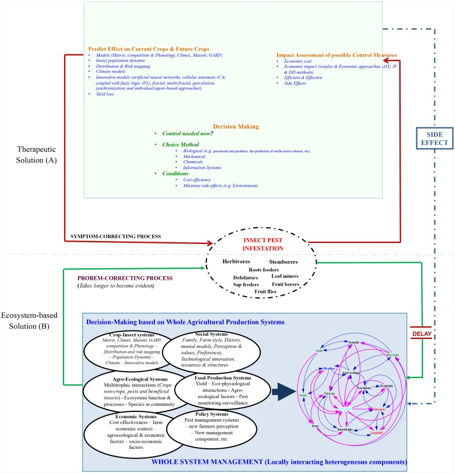

Fig. 7. Putting the system perspective into practice in pest management through intensified knowledge of ecosystem and therapeutics as backups. The systemic description allows identifying how reliance on therapeutic solutions can reinforce further reliance ‘side effect’. Bottom circle has a delay. It represents a more fundamental response to the pest problem, one whose effects take longer to become evident. Leverage will always involve strengthening the bottom circle and/or weakening the top circle.

The proposed system modelling recognizes the multiple ways in which pest problems can be addressed reaching from most fundamental based on intensified knowledge of agricultural production systems (Walters et al., 2016) to most superficial. Incorporation of this basic principle into the mainstreaming of pest management science and strategies needs also to consider the possible ‘reinforcing processes’ and negative ‘side effect’ of the therapeutic solutions to invoke the fundamental solution (Fig. 7). All these approaches belong to the traditional, scientific method for studying systems known as reductionism (Jackson, 2003). Reductionism perceives the components as paramount and seeks to identify and understand the components and thus derive an understanding of the whole system.

In summary, current modelling concepts of crop production consist of breaking down a system into components, seeking isolated understanding of individual components and intervene. In system modelling it is proposed to put the study of the whole before that of the components (Wallach et al., 2013, Fath, 2014, Walters et al., 2016). In doing so, the principle of the whole that emerges from the interactions between the components, which affect each other through complex networks of relationships, is respected. Indeed, we concur that there will be increasing need for model to improve control of pests and other components of on farm management. However, until these components are combined into a whole system approach, it will be difficult to achieve targets of sustainable management in crop production.

## Acknowledgments

This work is part of the fellowship project (VW-89362) of HEZT funded by the Volkswagen Foundation under the shame Funding Initiative Knowledge for Tomorrow − Cooperative Research Projects in Sub-Saharan on Resources, their Dynamics, and Sustainability − Capacity Development in Comparative and Integrated Approaches. The authors thank the Federal Ministry of Cooperation and Development (BMZ), Germany that provided the financial support through Tuta IPM project, and the Ministry for Foreign Affairs of Finland that provided financial support through CHIESA (Climate Change Impacts on Ecosystem Services and Food Security in Eastern Africa) project.

## References

**Addison, 2002**

P.S. Addison

**Fractals and Chaos: An Illustrated Course**

CRC Press (2002)

[Google Scholar](https://scholar.google.com/scholar_lookup?title=Fractals%20and%20Chaos%3A%20An%20Illustrated%20Course&publication_year=2002&author=P.S.%20Addison)

**Alston et al., 1995**

J.M. Alston, G.W. Norton, P.G. Pardey, *et al.*

**Science Under Scarcity: Principles and Practice for Agricultural Research Evaluation and Priority Setting**

Cornell University Press (1995)

Google Scholar

**Anderson et al., 2009**

K.E. Anderson, B.D. Inouye, N. Underwood

**Modeling herbivore competition mediated by inducible changes in plant quality**

Oikos, 118 (2009), pp. 1633-1646

[CrossRef](https://doi.org/10.1111/j.1600-0706.2009.17437.x)[View Record in Scopus](https://www.scopus.com/inward/record.url?eid=2-s2.0-71949121491&partnerID=10&rel=R3.0.0)Google Scholar

**Andriantiatsaholiniaina et al., 2004**

L.A. Andriantiatsaholiniaina, V.S. Kouikoglou, Y.A. Phillis

**Evaluating strategies for sustainable development: fuzzy logic reasoning and sensitivity analysis**

Ecol. Econ., 48 (2004), pp. 149-172

[Article](https://www.sciencedirect.com/science/article/pii/S0921800903002908)[Download PDF](https://www.sciencedirect.com/science/article/pii/S0921800903002908/pdfft?md5=5abbb47320331272a318d37b87079a64&pid=1-s2.0-S0921800903002908-main.pdf)[View Record in Scopus](https://www.scopus.com/inward/record.url?eid=2-s2.0-1242321376&partnerID=10&rel=R3.0.0)Google Scholar

**Araújo and New, 2007**

M.B. Araújo, M. New

**Ensemble forecasting of species distributions**

Trends Ecol. Evol., 22 (2007), pp. 42-47

[Article](https://www.sciencedirect.com/science/article/pii/S016953470600303X)[Download PDF](https://www.sciencedirect.com/science/article/pii/S016953470600303X/pdfft?md5=cebace00e4b3c7dd4935dec87423a805&pid=1-s2.0-S016953470600303X-main.pdf)[View Record in Scopus](https://www.scopus.com/inward/record.url?eid=2-s2.0-33845633261&partnerID=10&rel=R3.0.0)[Google Scholar](https://scholar.google.com/scholar_lookup?title=Ensemble%20forecasting%20of%20species%20distributions&publication_year=2007&author=M.B.%20Ara%C3%BAjo&author=M.%20New)

**Arenas et al., 2008**

A. Arenas, A. Díaz-Guilera, J. Kurths, Y. Moreno, C. Zhou

**Synchronization in complex networks**

Phys. Rep., 469 (2008), pp. 93-153

[Article](https://www.sciencedirect.com/science/article/pii/S0370157308003384)[Download PDF](https://www.sciencedirect.com/science/article/pii/S0370157308003384/pdfft?md5=5ed955780273bed859c515e332418885&pid=1-s2.0-S0370157308003384-main.pdf)Google Scholar

**Auld, 2002**

B. Auld

**Fungi as biocontrol agents: progress, problems and potential**

Plant Pathol., 51 (2002), p. 518

[View Record in Scopus](https://www.scopus.com/inward/record.url?eid=2-s2.0-85006452993&partnerID=10&rel=R3.0.0)[Google Scholar](https://scholar.google.com/scholar_lookup?title=Fungi%20as%20biocontrol%20agents%3A%20progress%2C%20problems%20and%20potential&publication_year=2002&author=B.%20Auld)

**Aurambout et al., 2009**

J.P. Aurambout, K.J. Finlay, J. Luck, G.A.C. Beattie

**A concept model to estimate the potential distribution of the Asiatic citrus psyllid (Diaphorina citri Kuwayama) in Australia under climate change—a means for assessing biosecurity risk**

Ecol. Model., 220 (2009), pp. 2512-2524

[Article](https://www.sciencedirect.com/science/article/pii/S0304380009003330)[Download PDF](https://www.sciencedirect.com/science/article/pii/S0304380009003330/pdfft?md5=ebfe864e4fa2ba04ebddca6aab09eada&pid=1-s2.0-S0304380009003330-main.pdf)[View Record in Scopus](https://www.scopus.com/inward/record.url?eid=2-s2.0-68949103883&partnerID=10&rel=R3.0.0)Google Scholar

**Bailey et al., 2000**

D.J. Bailey, W. Otten, C.A. Gilligan

**Saprotrophic invasion by the soil-borne fungal plant pathogen Rhizoctonia solani and percolation thresholds**

New Phytol., 146 (2000), pp. 535-544

[CrossRef](https://doi.org/10.1046/j.1469-8137.2000.00660.x)[View Record in Scopus](https://www.scopus.com/inward/record.url?eid=2-s2.0-0033949732&partnerID=10&rel=R3.0.0)Google Scholar

**Baret et al., 2007**

F. Baret, V. Houles, M. Guérif

**Quantification of plant stress using remote sensing observations and crop models: the case of nitrogen management**

J. Exp. Bot., 58 (2007), pp. 869-880

[View Record in Scopus](https://www.scopus.com/inward/record.url?eid=2-s2.0-33847629701&partnerID=10&rel=R3.0.0)Google Scholar

**Barratt et al., 2010**

B.I.P. Barratt, F.G. Howarth, T.M. Withers, J.M. Kean, G.S. Ridley

**Progress in risk assessment for classical biological control**

Biol. Control, 52 (2010), pp. 245-254

[Article](https://www.sciencedirect.com/science/article/pii/S1049964409000632)[Download PDF](https://www.sciencedirect.com/science/article/pii/S1049964409000632/pdfft?md5=062e43ddcf1f7ecdbb94ebfc59f8964e&pid=1-s2.0-S1049964409000632-main.pdf)[View Record in Scopus](https://www.scopus.com/inward/record.url?eid=2-s2.0-75449110148&partnerID=10&rel=R3.0.0)Google Scholar

**Bawden, 1991**

R.J. Bawden

**Systems thinking and practice in agriculture**

J. Dairy Sci., 74 (1991), pp. 2362-2373

[Article](https://www.sciencedirect.com/science/article/pii/S0022030291784105)[Download PDF](https://www.sciencedirect.com/science/article/pii/S0022030291784105/pdf?md5=63593df8863e8ac9aada077bf0fbfbe8&pid=1-s2.0-S0022030291784105-main.pdf)[View Record in Scopus](https://www.scopus.com/inward/record.url?eid=2-s2.0-0001452507&partnerID=10&rel=R3.0.0)[Google Scholar](https://scholar.google.com/scholar_lookup?title=Systems%20thinking%20and%20practice%20in%20agriculture&publication_year=1991&author=R.J.%20Bawden)

**Biber-Freudenberger et al., 2016**

L. Biber-Freudenberger, J. Ziemacki, H.E. Tonnang, C. Borgemeister

**Future risks of pest species under changing climatic conditions**

PLoS One, 11 (2016), p. e0153237

[CrossRef](https://doi.org/10.1371/journal.pone.0153237)[View Record in Scopus](https://www.scopus.com/inward/record.url?eid=2-s2.0-84963756635&partnerID=10&rel=R3.0.0)Google Scholar

**Blum et al., 2015**

M. Blum, I.M. Lensky, P. Rempoulakis, D. Nestel

**Modeling insect population fluctuations with satellite land surface temperature**

Ecol. Model., 311 (2015), pp. 39-47

[Article](https://www.sciencedirect.com/science/article/pii/S0304380015002021)[Download PDF](https://www.sciencedirect.com/science/article/pii/S0304380015002021/pdfft?md5=4518b31aa8d5470d4d6bf06972a4cfa9&pid=1-s2.0-S0304380015002021-main.pdf)[View Record in Scopus](https://www.scopus.com/inward/record.url?eid=2-s2.0-84930197246&partnerID=10&rel=R3.0.0)Google Scholar

**Bokonon-Ganta et al., 2002**

A.H. Bokonon-Ganta, H. de Groote, P. Neuenschwander

**Socio-economic impact of biological control of mango mealybug in Benin**

Agric. Ecosyst. Environ., 93 (2002), pp. 367-378

[Article](https://www.sciencedirect.com/science/article/pii/S0167880901003371)[Download PDF](https://www.sciencedirect.com/science/article/pii/S0167880901003371/pdfft?md5=75f5bdb7ea857c853ea132e0289e3784&pid=1-s2.0-S0167880901003371-main.pdf)[View Record in Scopus](https://www.scopus.com/inward/record.url?eid=2-s2.0-0036888881&partnerID=10&rel=R3.0.0)Google Scholar

**Bonabeau, 2002**

E. Bonabeau

**Agent-based modeling: Methods and techniques for simulating human systems**

Proceedings of the National Academy of Sciences, 99 (2002), pp. 7280-7287

[View Record in Scopus](https://www.scopus.com/inward/record.url?eid=2-s2.0-0037076425&partnerID=10&rel=R3.0.0)[Google Scholar](https://scholar.google.com/scholar_lookup?title=Agent-based%20modeling%3A%20Methods%20and%20techniques%20for%20simulating%20human%20systems&publication_year=2002&author=E.%20Bonabeau)

**Bone et al., 2006**

C. Bone, S. Dragicevic, A. Roberts

**A fuzzy-constrained cellular automata model of forest insect infestations**

Ecol. Model., 192 (2006), pp. 107-125

[Article](https://www.sciencedirect.com/science/article/pii/S0304380005004771)[Download PDF](https://www.sciencedirect.com/science/article/pii/S0304380005004771/pdfft?md5=3ac54cb314876f3cdde16047fe40d2a7&pid=1-s2.0-S0304380005004771-main.pdf)[View Record in Scopus](https://www.scopus.com/inward/record.url?eid=2-s2.0-31544448816&partnerID=10&rel=R3.0.0)Google Scholar

**Briere et al., 1999**

J.-F. Briere, P. Pracros, A.-Y. Le Roux, J.-S. Pierre

**A novel rate model of temperature-dependent development for arthropods**

Environ. Entomol., 28 (1999), pp. 22-29

[CrossRef](https://doi.org/10.1093/ee/28.1.22)Google Scholar

**Cao et al., 2013**

Y. Cao, R.E. DeWalt, J.L. Robinson, T. Tweddale, L. Hinz, M. Pessino

**Using Maxent to model the historic distributions of stonefly species in Illinois streams: the effects of regularization and threshold selections**

Ecol. Model., 259 (2013), pp. 30-39

[Article](https://www.sciencedirect.com/science/article/pii/S0304380013001695)[Download PDF](https://www.sciencedirect.com/science/article/pii/S0304380013001695/pdfft?md5=c8b7b1cceee7a35c75a5e9ece7219ab6&pid=1-s2.0-S0304380013001695-main.pdf)[CrossRef](https://doi.org/10.3901/JME.2013.18.030)[View Record in Scopus](https://www.scopus.com/inward/record.url?eid=2-s2.0-84876790334&partnerID=10&rel=R3.0.0)Google Scholar

**Carlberg et al., 2012**

E. Carlberg, G. Kostandini, A. Dankyi, *et al.*

**The effects of integrated pest management techniques (IPM) farmer field schools on groundnut productivity: evidence from Ghana**

Selected Paper Prepared for Presentation at the Agricultural & Applied Economics Association’s 2012 Annual Meeting (2012)

[Google Scholar](https://scholar.google.com/scholar?q=The%20effects%20of%20integrated%20pest%20management%20techniques%20%20farmer%20field%20schools%20on%20groundnut%20productivity:%20evidence%20from%20Ghana)

**Carter, 1996**

T.R. Carter

**Assessing climate change adaptations: the IPCC guidelines**

Adapting to Climate Change, Springer (1996), pp. 27-43

[CrossRef](https://doi.org/10.1007/978-1-4613-8471-7_4)[Google Scholar](https://scholar.google.com/scholar_lookup?title=Assessing%20climate%20change%20adaptations%3A%20the%20IPCC%20guidelines&publication_year=1996&author=T.R.%20Carter)

**Choi and Ryoo, 2003**

W.I. Choi, M.I. Ryoo

**A matrix model for predicting seasonal fluctuations in field populations of Paronychiurus kimi (Collembola: onychiruidae)**

Ecol. Model., 162 (2003), pp. 259-265

[Article](https://www.sciencedirect.com/science/article/pii/S0304380002003848)[Download PDF](https://www.sciencedirect.com/science/article/pii/S0304380002003848/pdfft?md5=b284bf9fbcf521dca00b55f0ca06faa6&pid=1-s2.0-S0304380002003848-main.pdf)[View Record in Scopus](https://www.scopus.com/inward/record.url?eid=2-s2.0-0037446407&partnerID=10&rel=R3.0.0)[Google Scholar](https://scholar.google.com/scholar?q=A%20matrix%20model%20for%20predicting%20seasonal%20fluctuations%20in%20field%20populations%20of%20Paronychiurus%20kimi)

**Chon et al., 2000**

T.-S. Chon, Y.-S. Park, J.-M. Kim, B.-Y. Lee, Y.-J. Chung, Y. Kim

**Use of an artificial neural network to predict population dynamics of the Forest–Pest pine needle gall midge (Diptera: cecidomyiida)**

Environ. Entomol., 29 (2000), pp. 1208-1215

[View Record in Scopus](https://www.scopus.com/inward/record.url?eid=2-s2.0-31544483594&partnerID=10&rel=R3.0.0)[Google Scholar](https://scholar.google.com/scholar?q=Use%20of%20an%20artificial%20neural%20network%20to%20predict%20population%20dynamics%20of%20the%20ForestPest%20pine%20needle%20gall%20midge)

**De Groote et al., 2003**

H. De Groote, O. Ajuonu, S. Attignon, R. Djessou, P. Neuenschwander

**Economic impact of biological control of water hyacinth in Southern Benin**

Ecol. Econ., 45 (2003), pp. 105-117

[Article](https://www.sciencedirect.com/science/article/pii/S0921800903000065)[Download PDF](https://www.sciencedirect.com/science/article/pii/S0921800903000065/pdfft?md5=e221d9c5ef1904307f8c31d4c0074d27&pid=1-s2.0-S0921800903000065-main.pdf)[View Record in Scopus](https://www.scopus.com/inward/record.url?eid=2-s2.0-0038404796&partnerID=10&rel=R3.0.0)Google Scholar

**De Janvry et al., 2000**

A. De Janvry, G. Graff, E. Sadoulet, D. Zilberman

**Technological change in agriculture and poverty reduction**

Concept Pap. WDR Poverty Dev. 2001 (2000)

Google Scholar

**De Meyer et al., 2010**

M. De Meyer, M.P. Robertson, M.W. Mansell, S. Ekesi, K. Tsuruta, W. Mwaiko, J.F. Vayssières, A.T. Peterson

**Ecological niche and potential geographic distribution of the invasive fruit fly Bactrocera invadens (Diptera, Tephritidae)**

Bull. Entomol. Res., 100 (2010), pp. 35-48

[View Record in Scopus](https://www.scopus.com/inward/record.url?eid=2-s2.0-77949722264&partnerID=10&rel=R3.0.0)[Google Scholar](https://scholar.google.com/scholar?q=Ecological%20niche%20and%20potential%20geographic%20distribution%20of%20the%20invasive%20fruit%20fly%20Bactrocera%20invadens)

**Desharnais et al., 2001**

R.A. Desharnais, R.F. Costantino, J.M. Cushing, S.M. Henson, B. Dennis

**Chaos and population control of insect outbreaks**

Ecol. Lett., 4 (2001), pp. 229-235

[View Record in Scopus](https://www.scopus.com/inward/record.url?eid=2-s2.0-0034986613&partnerID=10&rel=R3.0.0)Google Scholar

**Dimbi et al., 2009**

S. Dimbi, N.K. Maniania, S. Ekesi

**Effect of Metarhizium anisopliae inoculation on the mating behavior of three species of African Tephritid fruit flies, Ceratitis capitata, Ceratitis cosyra and Ceratitis fasciventris**

Biol. Control, 50 (2009), pp. 111-116

[Article](https://www.sciencedirect.com/science/article/pii/S1049964409001042)[Download PDF](https://www.sciencedirect.com/science/article/pii/S1049964409001042/pdfft?md5=981e8672241c9772f316f294a053835a&pid=1-s2.0-S1049964409001042-main.pdf)[View Record in Scopus](https://www.scopus.com/inward/record.url?eid=2-s2.0-65649142588&partnerID=10&rel=R3.0.0)Google Scholar

**Diuk-Wasser et al., 2010**

M.A. Diuk-Wasser, G. Vourc’h, P. Cislo, A.G. Hoen, F. Melton, S.A. Hamer, M. Rowland, R. Cortinas, G.J. Hickling, J.I. Tsao, *et al.*

**Field and climate-based model for predicting the density of host-seeking nymphal Ixodes scapularis, an important vector of tick-borne disease agents in the eastern United States**

Glob. Ecol. Biogeogr., 19 (2010), pp. 504-514

[View Record in Scopus](https://www.scopus.com/inward/record.url?eid=2-s2.0-77954820390&partnerID=10&rel=R3.0.0)Google Scholar

**Ehrlén and Morris, 2015**

J. Ehrlén, W.F. Morris

**Predicting changes in the distribution and abundance of species under environmental change**

Ecol. Lett., 18 (2015), pp. 303-314

[CrossRef](https://doi.org/10.1111/ele.12410)[View Record in Scopus](https://www.scopus.com/inward/record.url?eid=2-s2.0-84922650858&partnerID=10&rel=R3.0.0)Google Scholar

**Ekesi et al., 2002**

S. Ekesi, N.K. Maniania, S.A. Lux

**Mortality in three African tephritid fruit fly puparia and adults caused by the entomopathogenic fungi, Metarhizium anisopliae and Beauveria bassiana**

Biocontrol Sci. Technol., 12 (2002), pp. 7-17

[View Record in Scopus](https://www.scopus.com/inward/record.url?eid=2-s2.0-0036126391&partnerID=10&rel=R3.0.0)Google Scholar

**Elbehri and Macdonald, 2004**

A. Elbehri, S. Macdonald

**Estimating the impact of transgenic Bt cotton on West and Central Africa: a general equilibrium approach**

World Dev., 32 (2004), pp. 2049-2064

[Article](https://www.sciencedirect.com/science/article/pii/S0305750X04001512)[Download PDF](https://www.sciencedirect.com/science/article/pii/S0305750X04001512/pdfft?md5=6b57272e54128e9b8b4e65076eb83aac&pid=1-s2.0-S0305750X04001512-main.pdf)[View Record in Scopus](https://www.scopus.com/inward/record.url?eid=2-s2.0-8844278396&partnerID=10&rel=R3.0.0)Google Scholar

**Elith and Leathwick, 2009**

J. Elith, J.R. Leathwick

**Species distribution models: ecological explanation and prediction across space and time**

Annu. Rev. Ecol. Evol. Syst., 40 (2009), p. 677

[CrossRef](https://doi.org/10.1146/annurev.ecolsys.110308.120159)Google Scholar

**Ellner et al., 2002**

S.P. Ellner, Y. Seifu, R.H. Smith

**Fitting population dynamic models to time-series data by gradient matching**

Ecology, 83 (2002), pp. 2256-2270

[View Record in Scopus](https://www.scopus.com/inward/record.url?eid=2-s2.0-0037800363&partnerID=10&rel=R3.0.0)Google Scholar

**Fand et al., 2014a**

B.B. Fand, H.E. Tonnang, M. Kumar, S.K. Bal, N.P. Singh, D. Rao, A.L. Kamble, D.D. Nangare, P.S. Minhas

**Predicting the impact of climate change on regional and seasonal abundance of the mealybug Phenacoccus solenopsis Tinsley (Hemiptera: pseudococcidae) using temperature-driven phenology model linked to GIS**

Ecol. Model., 288 (2014), pp. 62-78

[Article](https://www.sciencedirect.com/science/article/pii/S0304380014002671)[Download PDF](https://www.sciencedirect.com/science/article/pii/S0304380014002671/pdfft?md5=4f600f6aa4271be1164026f4941caf4b&pid=1-s2.0-S0304380014002671-main.pdf)[View Record in Scopus](https://www.scopus.com/inward/record.url?eid=2-s2.0-84902578770&partnerID=10&rel=R3.0.0)Google Scholar

**Fand et al., 2014b**

B.B. Fand, H.E. Tonnang, M. Kumar, A.L. Kamble, S.K. Bal

**A temperature-based phenology model for predicting development, survival and population growth potential of the mealybug, Phenacoccus solenopsisTinsley (Hemiptera: pseudococcidae)**

Crop Prot., 55 (2014), pp. 98-108

[Article](https://www.sciencedirect.com/science/article/pii/S0261219413002676)[Download PDF](https://www.sciencedirect.com/science/article/pii/S0261219413002676/pdfft?md5=01c113f6494a0afedd0f30e357e383f4&pid=1-s2.0-S0261219413002676-main.pdf)[View Record in Scopus](https://www.scopus.com/inward/record.url?eid=2-s2.0-84887226766&partnerID=10&rel=R3.0.0)Google Scholar

**Fath, 2014**

B.D. Fath

**Sustainable systems promote wholeness-extending transformations: the contributions of systems thinking**

Ecol. Model., 293 (2014), pp. 42-48

[Article](https://www.sciencedirect.com/science/article/pii/S0304380014000362)[Download PDF](https://www.sciencedirect.com/science/article/pii/S0304380014000362/pdfft?md5=592841dca39a999ec6dcdb574db0cd9e&pid=1-s2.0-S0304380014000362-main.pdf)[View Record in Scopus](https://www.scopus.com/inward/record.url?eid=2-s2.0-84910633242&partnerID=10&rel=R3.0.0)Google Scholar

**Fiaboe et al., 2006**

K.K. Fiaboe, R.L. Fonseca, G.J. De Moraes, C.K. Ogol, M. Knapp

**Identification of priority areas in South America for exploration of natural enemies for classical biological control of Tetranychus evansi (Acari: tetranychidae) in Africa**

Biol. Control, 38 (2006), pp. 373-379

[Article](https://www.sciencedirect.com/science/article/pii/S1049964406001605)[Download PDF](https://www.sciencedirect.com/science/article/pii/S1049964406001605/pdfft?md5=ed9b47c0692db6ef82c445a1072163b0&pid=1-s2.0-S1049964406001605-main.pdf)[View Record in Scopus](https://www.scopus.com/inward/record.url?eid=2-s2.0-33746731089&partnerID=10&rel=R3.0.0)Google Scholar

**Filho et al., 2005**

T.M.R. Filho, I.M. Gléria, A. Figueiredo, L. Brenig

**The Lotka-Volterra canonical format**

Ecol. Model., 183 (2005), pp. 95-106, 10.1016/j.ecolmodel.2004.07.023

[Article](https://www.sciencedirect.com/science/article/pii/S0304380004004338)[Download PDF](https://www.sciencedirect.com/science/article/pii/S0304380004004338/pdfft?md5=ee7a6e7720737bc2e93f94b1f4132896&pid=1-s2.0-S0304380004004338-main.pdf)[Google Scholar](https://scholar.google.com/scholar_lookup?title=The%20Lotka-Volterra%20canonical%20format&publication_year=2005&author=T.M.R.%20Filho&author=I.M.%20Gl%C3%A9ria&author=A.%20Figueiredo&author=L.%20Brenig)

**Forkuo and Maathuis, 2012**

Forkuor, G., Maathuis, B., 2012. Comparison of SRTM and ASTER derived digital elevation models over two regions in Ghana-Implications for hydrological and environmental modeling: INTECH Open Access Publisher, 03-21.

Google Scholar

**Gamarra and He, 2008**

J.G.P. Gamarra, F. He

**Spatial scaling of mountain pine beetle infestations**

J. Anim. Ecol., 77 (2008), pp. 796-801

[CrossRef](https://doi.org/10.1111/j.1365-2656.2008.01389.x)[View Record in Scopus](https://www.scopus.com/inward/record.url?eid=2-s2.0-44849087613&partnerID=10&rel=R3.0.0)[Google Scholar](https://scholar.google.com/scholar_lookup?title=Spatial%20scaling%20of%20mountain%20pine%20beetle%20infestations&publication_year=2008&author=J.G.P.%20Gamarra&author=F.%20He)

**Garrett et al., 2013**

K.A. Garrett, A.D.M. Dobson, J. Kroschel, B. Natarajan, S. Orlandini, H.E. Tonnang, C. Valdivia

**The effects of climate variability and the color of weather time series on agricultural diseases and pests, and on decisions for their management**

Agric. For. Meteorol., 170 (2013), pp. 216-227

[Article](https://www.sciencedirect.com/science/article/pii/S016819231200158X)[Download PDF](https://www.sciencedirect.com/science/article/pii/S016819231200158X/pdfft?md5=80b2b28562c3baefc2027b8f1d6c44a2&pid=1-s2.0-S016819231200158X-main.pdf)[View Record in Scopus](https://www.scopus.com/inward/record.url?eid=2-s2.0-84872908172&partnerID=10&rel=R3.0.0)Google Scholar

**Grimm et al., 2005**

V. Grimm, E. Revilla, U. Berger, F. Jeltsch, W.M. Mooij, S.F. Railsback, H.-H. Thulke, J. Weiner, T. Wiegand, D.L. DeAngelis

**Pattern-oriented modeling of agent-based complex systems: lessons from ecology**

Science, 310 (2005), pp. 987-991

[CrossRef](https://doi.org/10.1126/science.1116681)[View Record in Scopus](https://www.scopus.com/inward/record.url?eid=2-s2.0-27744570841&partnerID=10&rel=R3.0.0)Google Scholar

**Grimmett, 1999**

G. Grimmett

**What Is Percolation?**

Springer (1999)

[Google Scholar](https://scholar.google.com/scholar?q=What%20Is%20Percolation)

**Guimapi et al., 2016**

R.Y. Guimapi, S.A. Mohamed, G.O. Okeyo, F.T. Ndjomatchoua, S. Ekesi, H.E. Tonnang

**Modeling the risk of invasion and spread of Tuta absoluta in Africa**

Ecol. Complex, 28 (2016), pp. 77-93, 10.1016/j.ecocom.2016.08.001

[Article](https://www.sciencedirect.com/science/article/pii/S1476945X16300575)[Download PDF](https://www.sciencedirect.com/science/article/pii/S1476945X16300575/pdfft?md5=d70e2b430e99647b7c7bed23571af5f9&pid=1-s2.0-S1476945X16300575-main.pdf)[View Record in Scopus](https://www.scopus.com/inward/record.url?eid=2-s2.0-84995686680&partnerID=10&rel=R3.0.0)Google Scholar

**Guisan and Thuiller, 2005**

A. Guisan, W. Thuiller

**Predicting species distribution: offering more than simple habitat models**

Ecol. Lett., 8 (2005), pp. 993-1009

[CrossRef](https://doi.org/10.1111/j.1461-0248.2005.00792.x)[View Record in Scopus](https://www.scopus.com/inward/record.url?eid=2-s2.0-24344493920&partnerID=10&rel=R3.0.0)[Google Scholar](https://scholar.google.com/scholar_lookup?title=Predicting%20species%20distribution%3A%20offering%20more%20than%20simple%20habitat%20models&publication_year=2005&author=A.%20Guisan&author=W.%20Thuiller)

**Guisan et al., 2013**

A. Guisan, R. Tingley, J.B. Baumgartner, I. Naujokaitis-Lewis, P.R. Sutcliffe, A.I. Tulloch, T.J. Regan, L. Brotons, E. McDonald-Madden, C. Mantyka-Pringle, *et al.*

**Predicting species distributions for conservation decisions**

Ecol. Lett., 16 (2013), pp. 1424-1435

[CrossRef](https://doi.org/10.1111/ele.12189)[View Record in Scopus](https://www.scopus.com/inward/record.url?eid=2-s2.0-84886730120&partnerID=10&rel=R3.0.0)Google Scholar

**Gutierrez et al., 1988**

A.P. Gutierrez, P. Neuenschwander, F. Schulthess, H.R. Herren, J.U. Baumgaertner, B. Wermelinger, B. Lohr, C.K. Ellis

**Analysis of biological control of cassava pests in Africa. II. Cassava mealybug Phenacoccus manihoti**

J. Appl. Ecol. (1988), pp. 921-940

[CrossRef](https://doi.org/10.2307/2403755)[View Record in Scopus](https://www.scopus.com/inward/record.url?eid=2-s2.0-0024189874&partnerID=10&rel=R3.0.0)Google Scholar

**Gutierrez et al., 1991**

A.P. Gutierrez, W.J. Dos Santos, M.A. Pizzamiglio, A.M. Villacorta, C.K. Ellis, C.A.P. Fernandes, I. Tutida

**Modelling the interaction of cotton and the cotton boll weevil. II. Bollweevil (Anthonomus grandis) in Brazil**

J. Appl. Ecol (1991), pp. 398-418

[CrossRef](https://doi.org/10.2307/2404558)[View Record in Scopus](https://www.scopus.com/inward/record.url?eid=2-s2.0-0026302537&partnerID=10&rel=R3.0.0)[Google Scholar](https://scholar.google.com/scholar?q=Modelling%20the%20interaction%20of%20cotton%20and%20the%20cotton%20boll%20weevil.%20II.%20Bollweevil%20%20in%20Brazil)

**Hartley et al., 2006**

S. Hartley, R. Harris, P.J. Lester

**Quantifying uncertainty in the potential distribution of an invasive species: climate and the Argentine ant**

Ecol. Lett., 9 (2006), pp. 1068-1079

[CrossRef](https://doi.org/10.1111/j.1461-0248.2006.00954.x)[View Record in Scopus](https://www.scopus.com/inward/record.url?eid=2-s2.0-33747604369&partnerID=10&rel=R3.0.0)Google Scholar

**Hastie and Fithian, 2013**

T. Hastie, W. Fithian

**Inference from presence-only data; the ongoing controversy**

Ecography, 36 (2013), pp. 864-867

[CrossRef](https://doi.org/10.1111/j.1600-0587.2013.00321.x)[View Record in Scopus](https://www.scopus.com/inward/record.url?eid=2-s2.0-84880039900&partnerID=10&rel=R3.0.0)[Google Scholar](https://scholar.google.com/scholar_lookup?title=Inference%20from%20presence-only%20data%3B%20the%20ongoing%20controversy&publication_year=2013&author=T.%20Hastie&author=W.%20Fithian)

**Huntley et al., 2004**

B. Huntley, R.E. Green, Y.C. Collingham, J.K. Hill, S.G. Willis, P.J. Bartlein, W. Cramer, W.J. Hagemeijer, C.J. Thomas

**The performance of models relating species geographical distributions to climate is independent of trophic level**

Ecol. Lett., 7 (2004), pp. 417-426

[View Record in Scopus](https://www.scopus.com/inward/record.url?eid=2-s2.0-2542420376&partnerID=10&rel=R3.0.0)Google Scholar

**Imbens and Wooldridge, 2008**

G.M. Imbens, J.M. Wooldridge

**Recent Developments in the Econometrics of Program Evaluation**

National Bureau of Economic Research (2008)

[Google Scholar](https://scholar.google.com/scholar_lookup?title=Recent%20Developments%20in%20the%20Econometrics%20of%20Program%20Evaluation&publication_year=2008&author=G.M.%20Imbens&author=J.M.%20Wooldridge)

**Jackson, 2003**

M.C. Jackson

**Systems Thinking: Creative Holism for Managers**

(2003)

[Google Scholar](https://scholar.google.com/scholar_lookup?title=Systems%20Thinking%3A%20Creative%20Holism%20for%20Managers&publication_year=2003&author=M.C.%20Jackson)

**Jonckheere et al., 2006**

I. Jonckheere, K. Nackaerts, B. Muys, J. van Aardt, P. Coppin

**A fractal dimension-based modelling approach for studying the effect of leaf distribution on LAI retrieval in forest canopies**

Ecol. Model., 197 (2006), pp. 179-195

[Article](https://www.sciencedirect.com/science/article/pii/S0304380006001001)[Download PDF](https://www.sciencedirect.com/science/article/pii/S0304380006001001/pdfft?md5=8929e8eaccf8cb16580f165ce3e462f8&pid=1-s2.0-S0304380006001001-main.pdf)[View Record in Scopus](https://www.scopus.com/inward/record.url?eid=2-s2.0-33746689218&partnerID=10&rel=R3.0.0)Google Scholar

**Jones et al., 1998**

J.W. Jones, J.C. Luyten, R.M. Peart, R.B. Curry

**Simulation of biological processes**

Agric. Syst. Model. Simul. (1998), pp. 19-62

[Google Scholar](https://scholar.google.com/scholar_lookup?title=Simulation%20of%20biological%20processes&publication_year=1998&author=J.W.%20Jones&author=J.C.%20Luyten&author=R.M.%20Peart&author=R.B.%20Curry)

**Kaplan and Denno, 2007**

I. Kaplan, R.F. Denno

**Interspecific interactions in phytophagous insects revisited: a quantitative assessment of competition theory**

Ecol. Lett., 10 (2007), pp. 977-994

[CrossRef](https://doi.org/10.1111/j.1461-0248.2007.01093.x)[View Record in Scopus](https://www.scopus.com/inward/record.url?eid=2-s2.0-34548527105&partnerID=10&rel=R3.0.0)Google Scholar

**Kari, 2005**

J. Kari

**Theory of cellular automata**

A survey. Theor. Comput. Sci., 334 (2005), pp. 3-33

[Article](https://www.sciencedirect.com/science/article/pii/S030439750500054X)[Download PDF](https://www.sciencedirect.com/science/article/pii/S030439750500054X/pdf?md5=e81df254001fc4f073d9da3b9929cc2b&pid=1-s2.0-S030439750500054X-main.pdf)[View Record in Scopus](https://www.scopus.com/inward/record.url?eid=2-s2.0-16444378043&partnerID=10&rel=R3.0.0)[Google Scholar](https://scholar.google.com/scholar_lookup?title=Theory%20of%20cellular%20automata&publication_year=2005&author=J.%20Kari)

**Kearney and Porter, 2009**

M. Kearney, W. Porter

**Mechanistic niche modelling: combining physiological and spatial data to predict species’ ranges**

Ecol. Lett., 12 (2009), pp. 334-350

[CrossRef](https://doi.org/10.1111/j.1461-0248.2008.01277.x)[View Record in Scopus](https://www.scopus.com/inward/record.url?eid=2-s2.0-62149086187&partnerID=10&rel=R3.0.0)[Google Scholar](https://scholar.google.com/scholar?q=Mechanistic%20niche%20modelling:%20combining%20physiological%20and%20spatial%20data%20to%20predict%20species%20ranges)

**Khadioli et al., 2014**

N. Khadioli, Z.E.H. Tonnang, G. Ong’amo, T. Achia, I. Kipchirchir, J. Kroschel, B. Le Ru

**Effect of temperature on the life history parameters of noctuid lepidopteran stem borers, Busseola fusca and Sesamia calamistis**

Ann. Appl. Biol., 165 (2014), pp. 373-386

[CrossRef](https://doi.org/10.1111/aab.12157)[View Record in Scopus](https://www.scopus.com/inward/record.url?eid=2-s2.0-84931271086&partnerID=10&rel=R3.0.0)Google Scholar

**Khandker et al., 2010**

S.R. Khandker, G.B. Koolwal, H.A. Samad

**Handbook on Impact Evaluation: Quantitative Methods and Practices**

World Bank Publications (2010)

Google Scholar

**Kibira, 2015**

M.N. Kibira

**Economic Evaluation of Integrated Pest Management Technology for Control of Mango Fruit Flies in Embu County, Kenya**

Kenyatta University (2015)

Google Scholar

**Kounatidis et al., 2008**

I. Kounatidis, N.T. Papadopoulos, P. Mavragani-Tsipidou, Y. Cohen, K. Tertivanidis, M. Nomikou, D. Nestel

**Effect of elevation on spatio-temporal patterns of olive fly (Bactrocera oleae) populations in northern Greece**

J. Appl. Entomol., 132 (2008), pp. 722-733, 10.1111/j.1439-0418.2008.01349.x

[View Record in Scopus](https://www.scopus.com/inward/record.url?eid=2-s2.0-58149178463&partnerID=10&rel=R3.0.0)[Google Scholar](https://scholar.google.com/scholar?q=Effect%20of%20elevation%20on%20spatio-temporal%20patterns%20of%20olive%20fly%20%20populations%20in%20northern%20Greece)

**Kroschel et al., 2013**

J. Kroschel, M. Sporleder, H.E.Z. Tonnang, H. Juarez, P. Carhuapoma, J.C. Gonzales, R. Simon

**Predicting climate-change-caused changes in global temperature on potato tuber moth Phthorimaea operculella (Zeller) distribution and abundance using phenology modeling and GIS mapping**

Agric. For. Meteorol., 170 (2013), pp. 228-241

[Article](https://www.sciencedirect.com/science/article/pii/S0168192312002341)[Download PDF](https://www.sciencedirect.com/science/article/pii/S0168192312002341/pdfft?md5=0a689694ac0c40f45cf74fbb2ce141e1&pid=1-s2.0-S0168192312002341-main.pdf)[View Record in Scopus](https://www.scopus.com/inward/record.url?eid=2-s2.0-84872955178&partnerID=10&rel=R3.0.0)Google Scholar

**Kuboka, 2013**

M.N. Kuboka

**Effect Of Temperature On The Efficacy Of Metarhizium Anisopliae (metchnikoff) Sorokin In The Control Of Western Flower Thrips In French Beans**

University of Nairobi (2013)

[Google Scholar](https://scholar.google.com/scholar?q=Effect%20Of%20Temperature%20On%20The%20Efficacy%20Of%20Metarhizium%20Anisopliae%20%20Sorokin%20In%20The%20Control%20Of%20Western%20Flower%20Thrips%20In%20French%20Beans)

**Lefkovitch, 1965**

L.P. Lefkovitch

**The study of population growth in organisms grouped by stages**

Biometrics (1965), pp. 1-18

[CrossRef](https://doi.org/10.2307/2528348)[Google Scholar](https://scholar.google.com/scholar_lookup?title=The%20study%20of%20population%20growth%20in%20organisms%20grouped%20by%20stages&publication_year=1965&author=L.P.%20Lefkovitch)

**Leslie, 1945**

P.H. Leslie

**On the use of matrices in certain population mathematics**

Biometrika, 33 (1945), pp. 183-212

[Google Scholar](https://scholar.google.com/scholar_lookup?title=On%20the%20use%20of%20matrices%20in%20certain%20population%20mathematics&publication_year=1945&author=P.H.%20Leslie)

**Lewis, 1977**

E.G. Lewis

**On the generation and growth of a population**

Mathematical Demography, Springer (1977), pp. 221-225

[CrossRef](https://doi.org/10.1007/978-3-642-81046-6_25)[View Record in Scopus](https://www.scopus.com/inward/record.url?eid=2-s2.0-85107621608&partnerID=10&rel=R3.0.0)[Google Scholar](https://scholar.google.com/scholar_lookup?title=On%20the%20generation%20and%20growth%20of%20a%20population&publication_year=1977&author=E.G.%20Lewis)

**Li, 2000**

B.-L. Li

**Fractal geometry applications in description and analysis of patch patterns and patch dynamics**

Ecol. Model., 132 (2000), pp. 33-50

[Article](https://www.sciencedirect.com/science/article/pii/S0304380000003033)[Download PDF](https://www.sciencedirect.com/science/article/pii/S0304380000003033/pdfft?md5=fe262a1e280507e9f9431ffdd3adb85e&pid=1-s2.0-S0304380000003033-main.pdf)[Google Scholar](https://scholar.google.com/scholar_lookup?title=Fractal%20geometry%20applications%20in%20description%20and%20analysis%20of%20patch%20patterns%20and%20patch%20dynamics&publication_year=2000&author=B.-L.%20Li)

**Logan et al., 2006**

J.D. Logan, W. Wolesensky, A. Joern

**Temperature-dependent phenology and predation in arthropod systems**

Ecol. Model., 196 (2006), pp. 471-482, 10.1016/j.ecolmodel.2006.02.034

[Article](https://www.sciencedirect.com/science/article/pii/S0304380006000913)[Download PDF](https://www.sciencedirect.com/science/article/pii/S0304380006000913/pdfft?md5=a3d9805debb761b440da4373a7d7b0c5&pid=1-s2.0-S0304380006000913-main.pdf)[View Record in Scopus](https://www.scopus.com/inward/record.url?eid=2-s2.0-33745464768&partnerID=10&rel=R3.0.0)Google Scholar

**Maiorano et al., 2012**

A. Maiorano, S. Bregaglio, M. Donatelli, D. Fumagalli, A. Zucchini

**Comparison of modelling approaches to simulate the phenology of the European corn borer under future climate scenarios**

Ecol. Model., 245 (2012), pp. 65-74, 10.1016/j.ecolmodel.2012.03.034

7th European Conference on Ecological Modelling (ECEM)

[Article](https://www.sciencedirect.com/science/article/pii/S0304380012001615)[Download PDF](https://www.sciencedirect.com/science/article/pii/S0304380012001615/pdfft?md5=12daa5e5a63ab8d7f1c239c7663acab1&pid=1-s2.0-S0304380012001615-main.pdf)[View Record in Scopus](https://www.scopus.com/inward/record.url?eid=2-s2.0-84866009499&partnerID=10&rel=R3.0.0)Google Scholar

**Maredia et al., 2000**

M. Maredia, D. Byerlee, J.R. Anderson

**Ex Post Evaluation of Economic Impacts of Agricultural Research Programs: a Tour of Good Practice**

(2000)

Google Scholar

**Masters, 1995**

W.A. Masters

**The Economic Impact of Agricultural Research: A Practical Guide**

Institut Du Sahel CILSS (1995)

[Google Scholar](https://scholar.google.com/scholar_lookup?title=The%20Economic%20Impact%20of%20Agricultural%20Research%3A%20A%20Practical%20Guide&publication_year=1995&author=W.A.%20Masters)

**Messenger, 1964**

P.S. Messenger

**Use of life tables in a bioclimatic study of an experimental aphid-braconid wasp host-parasite system**

Ecology (1964), pp. 119-131

[CrossRef](https://doi.org/10.2307/1937113)[View Record in Scopus](https://www.scopus.com/inward/record.url?eid=2-s2.0-0000678846&partnerID=10&rel=R3.0.0)Google Scholar

**Soul-kifouly et al., 2016**

Midingoyi Soul-kifouly, Hippolyte Affognon, Ibrahim Macharia, Georges Ong'amo, Esther Abonyo, Gerphas Ogola, Hugo De Groote Bruno LeRu

**Assessing the long-term welfare effects of the biological control of cereal stemborer pests in East and Southern Africa: Evidence from Kenya, Mozambique and Zambia**

Agric. Ecosyst. Environ., 230 (2016), pp. 10-23

Google Scholar

**Mills and Getz, 1996**

N.J. Mills, W.M. Getz

**Modelling the biological control of insect pests: a review of host-parasitoid models**

Ecol. Model., 92 (1996), pp. 121-143

[Article](https://www.sciencedirect.com/science/article/pii/0304380095001778)[Download PDF](https://www.sciencedirect.com/science/article/pii/0304380095001778/pdf?md5=057cbf5aad4d19cf9d2663a7a03a1026&pid=1-s2.0-0304380095001778-main.pdf)[View Record in Scopus](https://www.scopus.com/inward/record.url?eid=2-s2.0-0030302709&partnerID=10&rel=R3.0.0)Google Scholar

**Muriithi et al., 2016**

B.W. Muriithi, H.D. Affognon, G.M. Diiro, S.W. Kingori, C.M. Tanga, P.W. Nderitu, S.A. Mohamed, S. Ekesi

**Impact assessment of Integrated Pest Management (IPM) strategy for suppression of mango-infesting fruit flies in Kenya**

Crop Prot., 81 (2016), pp. 20-29

[Article](https://www.sciencedirect.com/science/article/pii/S0261219415301678)[Download PDF](https://www.sciencedirect.com/science/article/pii/S0261219415301678/pdfft?md5=82709d2f3af64b14cff655adbd97335e&pid=1-s2.0-S0261219415301678-main.pdf)[View Record in Scopus](https://www.scopus.com/inward/record.url?eid=2-s2.0-84949920897&partnerID=10&rel=R3.0.0)[Google Scholar](https://scholar.google.com/scholar?q=Impact%20assessment%20of%20Integrated%20Pest%20Management%20%20strategy%20for%20suppression%20of%20mango-infesting%20fruit%20flies%20in%20Kenya)

**Mwalusepo et al., 2014**

S. Mwalusepo, H.E. Tonnang, E.S. Massawe, T. Johansson, B.P. Le Ru

**Stability analysis of competing insect species for a single resource**

J. Appl. Math., 2014 (2014)

Google Scholar

**Mwalusepo et al., 2015**

S. Mwalusepo, H.E. Tonnang, E.S. Massawe, G.O. Okuku, N. Khadioli, T. Johansson, P.-A. Calatayud, B.P. Le Ru

**Predicting the impact of temperature change on the future distribution of maize stem borers and their natural enemies along east african mountain gradients using phenology models**

PLoS One, 10 (2015), p. e0130427

[CrossRef](https://doi.org/10.1371/journal.pone.0130427)[View Record in Scopus](https://www.scopus.com/inward/record.url?eid=2-s2.0-84953911396&partnerID=10&rel=R3.0.0)Google Scholar

**Nakanishi and Cooper, 1974**

M. Nakanishi, L.G. Cooper

**Parameter estimation for a multiplicative competitive interaction model: least squares approach**

J. Mark. Res. (1974), pp. 303-311

Google Scholar

**Nazli, 2010**

H. Nazli

**Impact of Bt Cotton Adoption on Farmers’wellbeing in Pakistan**

The University of Guelph (2010)

[Google Scholar](https://scholar.google.com/scholar?q=Impact%20of%20Bt%20Cotton%20Adoption%20on%20Farmerswellbeing%20in%20Pakistan)

**Ndjomatchoua et al., 2016**

F.T. Ndjomatchoua, H.E. Tonnang, C. Plantamp, P. Campagne, C. Tchawoua, B.P. Le Ru

**Spatial and temporal spread of maize stem borer Busseola fusca (Fuller) (Lepidoptera: noctuidae) damage in smallholder farms**

Agric. Ecosyst. Environ., 235 (2016), pp. 105-118

[Article](https://www.sciencedirect.com/science/article/pii/S0167880916305059)[Download PDF](https://www.sciencedirect.com/science/article/pii/S0167880916305059/pdfft?md5=9d7aa72f90131d5e3a40790b7756fe72&pid=1-s2.0-S0167880916305059-main.pdf)[View Record in Scopus](https://www.scopus.com/inward/record.url?eid=2-s2.0-84992697443&partnerID=10&rel=R3.0.0)[Google Scholar](https://scholar.google.com/scholar?q=Spatial%20and%20temporal%20spread%20of%20maize%20stem%20borer%20Busseola%20fusca%20%20%20damage%20in%20smallholder%20farms)

**Nedorezov et al., 2008**

L.V. Nedorezov, B.L. Löhr, D.L. Sadykova

**Assessing the importance of self-regulating mechanisms in diamondback moth population dynamics: application of discrete mathematical models**

J. Theor. Biol., 254 (2008), pp. 587-593

[Article](https://www.sciencedirect.com/science/article/pii/S0022519308003421)[Download PDF](https://www.sciencedirect.com/science/article/pii/S0022519308003421/pdfft?md5=8c902ab81926c2fed69ad0c4ec41513f&pid=1-s2.0-S0022519308003421-main.pdf)[View Record in Scopus](https://www.scopus.com/inward/record.url?eid=2-s2.0-51549104846&partnerID=10&rel=R3.0.0)Google Scholar

**Norgaard, 1988**

R.B. Norgaard

**The biological control of cassava mealybug in Africa**

Am. J. Agric. Econ., 70 (1988), pp. 366-371

[CrossRef](https://doi.org/10.2307/1242077)[View Record in Scopus](https://www.scopus.com/inward/record.url?eid=2-s2.0-0024250363&partnerID=10&rel=R3.0.0)[Google Scholar](https://scholar.google.com/scholar_lookup?title=The%20biological%20control%20of%20cassava%20mealybug%20in%20Africa&publication_year=1988&author=R.B.%20Norgaard)

**Pearse and Altermatt, 2013**

I.S. Pearse, F. Altermatt

**Predicting novel trophic interactions in a non-native world**

Ecol. Lett., 16 (2013), pp. 1088-1094

[CrossRef](https://doi.org/10.1111/ele.12143)[View Record in Scopus](https://www.scopus.com/inward/record.url?eid=2-s2.0-84880340748&partnerID=10&rel=R3.0.0)[Google Scholar](https://scholar.google.com/scholar_lookup?title=Predicting%20novel%20trophic%20interactions%20in%20a%20non-native%20world&publication_year=2013&author=I.S.%20Pearse&author=F.%20Altermatt)

**Perfecto and Vandermeer, 2008**

I. Perfecto, J. Vandermeer

**Spatial pattern and ecological process in the coffee agroforestry system**

Ecology, 89 (4) (2008), pp. 915-920

[CrossRef](https://doi.org/10.1890/06-2121.1)[View Record in Scopus](https://www.scopus.com/inward/record.url?eid=2-s2.0-42949147760&partnerID=10&rel=R3.0.0)[Google Scholar](https://scholar.google.com/scholar_lookup?title=Spatial%20pattern%20and%20ecological%20process%20in%20the%20coffee%20agroforestry%20system&publication_year=2008&author=I.%20Perfecto&author=J.%20Vandermeer)

**Petacchi et al., 2015**

R. Petacchi, S. Marchi, S. Federici, G. Ragaglini

**Large-scale simulation of temperature-dependent phenology in wintering populations of Bactrocera oleae (Rossi)**

J. Appl. Entomol., 139 (2015), pp. 496-509, 10.1111/jen.12189

[View Record in Scopus](https://www.scopus.com/inward/record.url?eid=2-s2.0-84935042950&partnerID=10&rel=R3.0.0)[Google Scholar](https://scholar.google.com/scholar?q=Large-scale%20simulation%20of%20temperature-dependent%20phenology%20in%20wintering%20populations%20of%20Bactrocera%20oleae)

**Pilkington and Hoddle, 2006**

L.J. Pilkington, M.S. Hoddle

**Use of life table statistics and degree-day values to predict the invasion success of Gonatocerus ashmeadi (Hymenoptera: mymaridae), an egg parasitoid of Homalodisca coagulate (Hemiptera: cicadellidae), in California**

Biol. Control, 37 (2006), pp. 276-283

[Article](https://www.sciencedirect.com/science/article/pii/S1049964406000491)[Download PDF](https://www.sciencedirect.com/science/article/pii/S1049964406000491/pdfft?md5=a669955403bcce2af762af7a1898b335&pid=1-s2.0-S1049964406000491-main.pdf)[View Record in Scopus](https://www.scopus.com/inward/record.url?eid=2-s2.0-33646180024&partnerID=10&rel=R3.0.0)Google Scholar

**Recknagel, 2001**

F. Recknagel

**Applications of machine learning to ecological modelling**

Ecol. Model., 146 (2001), pp. 303-310

[Article](https://www.sciencedirect.com/science/article/pii/S0304380001003167)[Download PDF](https://www.sciencedirect.com/science/article/pii/S0304380001003167/pdfft?md5=88e59e6d5b4bb03531d5c93663430100&pid=1-s2.0-S0304380001003167-main.pdf)[View Record in Scopus](https://www.scopus.com/inward/record.url?eid=2-s2.0-0035676249&partnerID=10&rel=R3.0.0)[Google Scholar](https://scholar.google.com/scholar_lookup?title=Applications%20of%20machine%20learning%20to%20ecological%20modelling&publication_year=2001&author=F.%20Recknagel)

**Rejesus et al., 2009**

R.M. Rejesus, F.G. Palis, A.V. Lapitan, T.T.N. Chi, M. Hossain

**The impact of integrated pest management information dissemination methods on insecticide use and efficiency: evidence from rice producers in South Vietnam**

Appl. Econ. Perspect. Policy, 31 (2009), pp. 814-833

[CrossRef](https://doi.org/10.1111/j.1467-9353.2009.01468.x)[View Record in Scopus](https://www.scopus.com/inward/record.url?eid=2-s2.0-71849088213&partnerID=10&rel=R3.0.0)Google Scholar

**Ren et al., 2012**

D. Ren, H. Yu, W. Fu, B. Zhang, Q. Ji

**Crop diseases and pests monitoring based on remote sensing: a survey**

World Automation Congress (WAC), 2012. IEEE (2012), pp. 177-181

[CrossRef](https://doi.org/10.1109/ICoOM.2012.6316245)[View Record in Scopus](https://www.scopus.com/inward/record.url?eid=2-s2.0-84869178848&partnerID=10&rel=R3.0.0)Google Scholar

**Sanglestsawai et al., 2015**

S. Sanglestsawai, R.M. Rejesus, J.M. Yorobe

**Economic impacts of integrated pest management (IPM) farmer field schools (FFS): evidence from onion farmers in the Philippines**

Agric. Econ., 46 (2015), pp. 149-162

[CrossRef](https://doi.org/10.1111/agec.12147)[View Record in Scopus](https://www.scopus.com/inward/record.url?eid=2-s2.0-84924534614&partnerID=10&rel=R3.0.0)[Google Scholar](https://scholar.google.com/scholar?q=Economic%20impacts%20of%20integrated%20pest%20management%20%20farmer%20field%20schools%20:%20evidence%20from%20onion%20farmers%20in%20the%20Philippines)

**Shelton et al., 2002**

A.M. Shelton, J.-Z. Zhao, R.T. Roush

**Economic, ecological, food safety, and social consequences of the deployment of Bt transgenic plants**

Annu. Rev. Entomol., 47 (2002), pp. 845-881

[CrossRef](https://doi.org/10.1146/annurev.ento.47.091201.145309)[View Record in Scopus](https://www.scopus.com/inward/record.url?eid=2-s2.0-0036006847&partnerID=10&rel=R3.0.0)Google Scholar

**Smith and Conrey, 2007**

E.R. Smith, F.R. Conrey

**Agent-based modeling: a new approach for theory building in social psychology**

Personal. Soc. Psychol. Rev., 11 (2007), pp. 87-104

[CrossRef](https://doi.org/10.1177/1088868306294789)[View Record in Scopus](https://www.scopus.com/inward/record.url?eid=2-s2.0-34547297912&partnerID=10&rel=R3.0.0)Google Scholar

**Sporleder et al., 2013**

M. Sporleder, H.E.Z. Tonnang, P. Carhuapoma, J.C. Gonzales, H. Juarez, J. Kroschel, J.E. Peña, *et al.*

**Insect Life Cycle Modelling (ILCYM) software-a new tool for regional and global insect pest risk assessments under current and future climate change scenarios**

Potential Invasive Pests Agric. Crops (2013), pp. 412-427

[CrossRef](https://doi.org/10.1079/9781845938291.0412)[View Record in Scopus](https://www.scopus.com/inward/record.url?eid=2-s2.0-84891034933&partnerID=10&rel=R3.0.0)Google Scholar

**Stockwell, 1999**

D. Stockwell

**The GARP modelling system: problems and solutions to automated spatial prediction**

Int. J. Geogr. Inf. Sci., 13 (1999), pp. 143-158

[View Record in Scopus](https://www.scopus.com/inward/record.url?eid=2-s2.0-0032903209&partnerID=10&rel=R3.0.0)[Google Scholar](https://scholar.google.com/scholar_lookup?title=The%20GARP%20modelling%20system%3A%20problems%20and%20solutions%20to%20automated%20spatial%20prediction&publication_year=1999&author=D.%20Stockwell)

**Stokland et al., 2011**

J.N. Stokland, R. Halvorsen, B. Støa

**Species distribution modelling—effect of design and sample size of pseudo-absence observations**

Ecol. Model., 222 (2011), pp. 1800-1809

[Article](https://www.sciencedirect.com/science/article/pii/S0304380011001062)[Download PDF](https://www.sciencedirect.com/science/article/pii/S0304380011001062/pdfft?md5=98ffebafa0c46bb001a6abd1ddb15dcc&pid=1-s2.0-S0304380011001062-main.pdf)[View Record in Scopus](https://www.scopus.com/inward/record.url?eid=2-s2.0-79955109768&partnerID=10&rel=R3.0.0)[Google Scholar](https://scholar.google.com/scholar?q=Species%20distribution%20modellingeffect%20of%20design%20and%20sample%20size%20of%20pseudo-absence%20observations)

**Stott and Kettleborough, 2002**

P.A. Stott, J.A. Kettleborough

**Origins and estimates of uncertainty in predictions of twenty-first century temperature rise**

Nature, 416 (2002), pp. 723-726

[View Record in Scopus](https://www.scopus.com/inward/record.url?eid=2-s2.0-0037129227&partnerID=10&rel=R3.0.0)Google Scholar

**Sultan et al., 2014**

B. Sultan, K. Guan, M. Kouressy, M. Biasutti, C. Piani, G.L. Hammer, G. McLean, D.B. Lobell

**Robust features of future climate change impacts on sorghum yields in West Africa**

Environ. Res. Lett., 9 (2014), p. 104006

[CrossRef](https://doi.org/10.1088/1748-9326/9/10/104006)[View Record in Scopus](https://www.scopus.com/inward/record.url?eid=2-s2.0-84907888740&partnerID=10&rel=R3.0.0)Google Scholar

**Sutherst and Maywald, 1985**

R.W. Sutherst, G.F. Maywald

**A computerised system for matching climates in ecology**

Agric. Ecosyst. Environ., 13 (1985), pp. 281-299

[Article](https://www.sciencedirect.com/science/article/pii/0167880985900167)[Download PDF](https://www.sciencedirect.com/science/article/pii/0167880985900167/pdf?md5=94c2dc34f8655137a401f9378c979e19&pid=1-s2.0-0167880985900167-main.pdf)[View Record in Scopus](https://www.scopus.com/inward/record.url?eid=2-s2.0-0022179208&partnerID=10&rel=R3.0.0)[Google Scholar](https://scholar.google.com/scholar_lookup?title=A%20computerised%20system%20for%20matching%20climates%20in%20ecology&publication_year=1985&author=R.W.%20Sutherst&author=G.F.%20Maywald)

**Sutherst, 2003**

R.W. Sutherst

**Prediction of species geographical ranges**

J. Biogeogr., 30 (2003), pp. 805-816

[View Record in Scopus](https://www.scopus.com/inward/record.url?eid=2-s2.0-0038275929&partnerID=10&rel=R3.0.0)[Google Scholar](https://scholar.google.com/scholar_lookup?title=Prediction%20of%20species%20geographical%20ranges&publication_year=2003&author=R.W.%20Sutherst)

**Swed and Eisenhart, 1943**

F.S. Swed, C. Eisenhart

**Tables for testing randomness of grouping in a sequence of alternatives**

Ann. Math. Stat., 14 (1943), pp. 66-87

[CrossRef](https://doi.org/10.1214/aoms/1177731494)[View Record in Scopus](https://www.scopus.com/inward/record.url?eid=2-s2.0-0001885455&partnerID=10&rel=R3.0.0)[Google Scholar](https://scholar.google.com/scholar_lookup?title=Tables%20for%20testing%20randomness%20of%20grouping%20in%20a%20sequence%20of%20alternatives&publication_year=1943&author=F.S.%20Swed&author=C.%20Eisenhart)

**Thomas, 2001**

C.D. Thomas

**Scale, dispersal and 1 5 population structure**

Insect Movement: Mechanisms and Consequences: Proceedings of the Royal Entomological Society’s 20th Symposium, CABI (2001), p. 321

[CrossRef](https://doi.org/10.1079/9780851994567.0321)[Google Scholar](https://scholar.google.com/scholar_lookup?title=Scale%2C%20dispersal%20and%201%205%20population%20structure&publication_year=2001&author=C.D.%20Thomas)

**Thornton et al., 2009**

P.K. Thornton, P.G. Jones, G. Alagarswamy, J. Andresen

**Spatial variation of crop yield response to climate change in East Africa**

Glob. Environ. Change, 19 (2009), pp. 54-65

[Article](https://www.sciencedirect.com/science/article/pii/S0959378008000812)[Download PDF](https://www.sciencedirect.com/science/article/pii/S0959378008000812/pdfft?md5=7c60d5506a63cc07aa8aeb026b249224&pid=1-s2.0-S0959378008000812-main.pdf)[View Record in Scopus](https://www.scopus.com/inward/record.url?eid=2-s2.0-60849129439&partnerID=10&rel=R3.0.0)Google Scholar

**Tonnang et al., 2009**

H.E. Tonnang, L.V. Nedorezov, H. Ochanda, J. Owino, B. Löhr

**Assessing the impact of biological control of Plutella xylostella through the application of Lotka–Volterra model**

Ecol. Model., 220 (2009), pp. 60-70

[Article](https://www.sciencedirect.com/science/article/pii/S0304380008004298)[Download PDF](https://www.sciencedirect.com/science/article/pii/S0304380008004298/pdfft?md5=d07b73306162ca5dc9923803b713d304&pid=1-s2.0-S0304380008004298-mainext.pdf)[View Record in Scopus](https://www.scopus.com/inward/record.url?eid=2-s2.0-56349116724&partnerID=10&rel=R3.0.0)[Google Scholar](https://scholar.google.com/scholar?q=Assessing%20the%20impact%20of%20biological%20control%20of%20Plutella%20xylostella%20through%20the%20application%20of%20LotkaVolterra%20model)

**Tonnang et al., 2010**

H.E. Tonnang, L.V. Nedorezov, J.O. Owino, H. Ochanda, B. Löhr

**Host–parasitoid population density prediction using artificial neural networks: diamondback moth and its natural enemies**

Agric. For. Entomol., 12 (2010), pp. 233-242

[View Record in Scopus](https://www.scopus.com/inward/record.url?eid=2-s2.0-77954488217&partnerID=10&rel=R3.0.0)[Google Scholar](https://scholar.google.com/scholar?q=Hostparasitoid%20population%20density%20prediction%20using%20artificial%20neural%20networks:%20diamondback%20moth%20and%20its%20natural%20enemies)

**Tonnang et al., 2015**

H.E. Tonnang, S.A. Mohamed, F. Khamis, S. Ekesi

**Correction: identification and risk assessment for worldwide invasion and spread of tuta absoluta with a focus on Sub-Saharan Africa: implications for phytosanitary measures and management**

PloS One, 10 (2017), p. 1371, 10.1371/journal.pone.0135283

Google Scholar

**Tscharntke et al., 2011**

T. Tscharntke, Y. Clough, S.A. Bhagwat, D. Buchori, H. Faust, D. Hertel, D. Holscher, J. Juhrbandt, M. Kessler, I. Perfecto, C. Scherber, G. Schroth, E. Veldkamp, T.C. Wanger

**Multifunctional shade-tree management in tropical agroforestry landscapes—a review**

J. Appl. Ecol., 48 (2011), pp. 619-629

[CrossRef](https://doi.org/10.1111/j.1365-2664.2010.01939.x)[View Record in Scopus](https://www.scopus.com/inward/record.url?eid=2-s2.0-79955979974&partnerID=10&rel=R3.0.0)[Google Scholar](https://scholar.google.com/scholar?q=Multifunctional%20shade-tree%20management%20in%20tropical%20agroforestry%20landscapesa%20review)

**Tscharntke et al., 2012**

T. Tscharntke, J.M. Tylianakis, T.A. Rand, R.K. Didham, L. Fahrig, P. Batáry, J. Bengtsson, Y. Clough, O.T. Crist, C.F. Dormann, R.W. Ewers, J. Fründ, R.D. Holt, A. Holzschuh, A.M. Klein, D. Kleijn, C. Kremen, D.A. Landis, W. Laurance, D. Lindenmayer, C. Scherber, N. Sodhi, I. Steffan-Dewenter, C. Thies, W.H. van der Putten, C. Westphal

**Landscape moderation of biodiversity patterns and processes – eight hypotheses**

Biol. Rev., 87 (2012), pp. 661-685

[View Record in Scopus](https://www.scopus.com/inward/record.url?eid=2-s2.0-84861670005&partnerID=10&rel=R3.0.0)[Google Scholar](https://scholar.google.com/scholar?q=Landscape%20moderation%20of%20biodiversity%20patterns%20and%20processes%20%20eight%20hypotheses)

**Van Ittersum et al., 2003**

M.K. Van Ittersum, P.A. Leffelaar, H. Van Keulen, M.J. Kropff, L. Bastiaans, J. Goudriaan

**On approaches and applications of the Wageningen crop models**

Eur. J. Agron., 18 (2003), pp. 201-234

[Article](https://www.sciencedirect.com/science/article/pii/S1161030102001065)[Download PDF](https://www.sciencedirect.com/science/article/pii/S1161030102001065/pdfft?md5=1b7f088baf58fa11a89058e2fc14ab65&pid=1-s2.0-S1161030102001065-main.pdf)[View Record in Scopus](https://www.scopus.com/inward/record.url?eid=2-s2.0-0037232350&partnerID=10&rel=R3.0.0)Google Scholar

**Venette et al., 2010**

R.C. Venette, D.J. Kriticos, R.D. Magarey, F.H. Koch, R.H. Baker, S.P. Worner, N.N.G. Raboteaux, D.W. McKenney, E.J. Dobesberger, D. Yemshanov, *et al.*

**Pest risk maps for invasive alien species: a roadmap for improvement**

Bioscience, 60 (2010), pp. 349-362

[CrossRef](https://doi.org/10.1525/bio.2010.60.5.5)[View Record in Scopus](https://www.scopus.com/inward/record.url?eid=2-s2.0-77952150448&partnerID=10&rel=R3.0.0)Google Scholar

**Wallach et al., 2013**

D. Wallach, D. Makowski, J.W. Jones, F. Brun

**Working with Dynamic Crop Models: Methods, Tools and Examples for Agriculture and Environment**

Academic Press (2013)

Google Scholar

**Walters et al., 2016**

J.P. Walters, D.W. Archer, G.F. Sassenrath, J.R. Hendrickson, J.D. Hanson, J.M. Halloran, P. Vadas, V.J. Alarcon

**Exploring agricultural production systems and their fundamental components with system dynamics modelling**

Ecol. Model., 333 (2016), pp. 51-65

[Article](https://www.sciencedirect.com/science/article/pii/S0304380016301417)[Download PDF](https://www.sciencedirect.com/science/article/pii/S0304380016301417/pdfft?md5=3831e8817225a64cb8da9b0b2e301202&pid=1-s2.0-S0304380016301417-main.pdf)[View Record in Scopus](https://www.scopus.com/inward/record.url?eid=2-s2.0-84966377289&partnerID=10&rel=R3.0.0)Google Scholar

**Watson et al., 1998**

R.T. Watson, M.C. Zinyowera, R.H. Moss

**The Regional Impacts of Climate Change: an Assessment of Vulnerability**

Cambridge University Press (1998)

Google Scholar

**Watts and Worner, 2009**

M.J. Watts, S.P. Worner

**Estimating the risk of insect species invasion: kohonen self-organising maps versus k-means clustering**

Ecol. Model., 220 (2009), pp. 821-829

[Article](https://www.sciencedirect.com/science/article/pii/S0304380008005966)[Download PDF](https://www.sciencedirect.com/science/article/pii/S0304380008005966/pdfft?md5=edf33423faaf8efc32000d2999351aa6&pid=1-s2.0-S0304380008005966-main.pdf)[View Record in Scopus](https://www.scopus.com/inward/record.url?eid=2-s2.0-60649120714&partnerID=10&rel=R3.0.0)Google Scholar

**Wielgoss et al., 2012**

A. Wielgoss, Y. Clough, B. Fiala, A. Remede, T. Tscharntke

**A minor pest reduces yield losses by a major pest: plant-mediated herbivore interactions in Indonesian cacao**

J. Appl. Ecol., 49 (2012), pp. 465-473

[CrossRef](https://doi.org/10.1111/j.1365-2664.2012.02122.x)[View Record in Scopus](https://www.scopus.com/inward/record.url?eid=2-s2.0-84859160181&partnerID=10&rel=R3.0.0)Google Scholar

**Wiens et al., 1997**

J.A. Wiens, R.L. Schooley, R.D. Weeks Jr

**Patchy landscapes and animal movements: do beetles percolate?**

Oikos (1997), pp. 257-264

[CrossRef](https://doi.org/10.2307/3546292)[View Record in Scopus](https://www.scopus.com/inward/record.url?eid=2-s2.0-0030620794&partnerID=10&rel=R3.0.0)[Google Scholar](https://scholar.google.com/scholar?q=Patchy%20landscapes%20and%20animal%20movements:%20do%20beetles%20percolate)

**Wilby and Thomas, 2002**

A. Wilby, M.B. Thomas

**Natural enemy diversity and pest control: patterns of pest emergence with agricultural intensification**

Ecol. Lett., 5 (2002), pp. 353-360

[View Record in Scopus](https://www.scopus.com/inward/record.url?eid=2-s2.0-0036091257&partnerID=10&rel=R3.0.0)Google Scholar

**With et al., 2002**

K.A. With, D.M. Pavuk, J.L. Worchuck, R.K. Oates, J.L. Fisher

**Threshold effects of landscape structure on biological control in agroecosystems**

Ecol. Appl., 12 (2002), pp. 52-65

[View Record in Scopus](https://www.scopus.com/inward/record.url?eid=2-s2.0-0036166113&partnerID=10&rel=R3.0.0)Google Scholar

**Yang et al., 2009**

L. Yang, L. Peng, L. Zhang, L. Zhang, S. Yang

**A prediction model for population occurrence of paddy stem borer (Scirpophaga incertulas), based on Back Propagation Artificial Neural Network and Principal Components Analysis**

Comput. Electron. Agric., 68 (2009), pp. 200-206

[Article](https://www.sciencedirect.com/science/article/pii/S0168169909000970)[Download PDF](https://www.sciencedirect.com/science/article/pii/S0168169909000970/pdfft?md5=2a0b851aaf3be79de38be950a26d88a4&pid=1-s2.0-S0168169909000970-main.pdf)[View Record in Scopus](https://www.scopus.com/inward/record.url?eid=2-s2.0-67650526155&partnerID=10&rel=R3.0.0)Google Scholar

**Zeddies et al., 2001**

J. Zeddies, R.P. Schaab, P. Neuenschwander, H.R. Herren

**Economics of biological control of cassava mealybug in Africa**

Agric. Econ., 24 (2001), pp. 209-219

[Article](https://www.sciencedirect.com/science/article/pii/S0169515000000645)[Download PDF](https://www.sciencedirect.com/science/article/pii/S0169515000000645/pdfft?md5=1d63337cea913a4882e2db9c9dbca660&pid=1-s2.0-S0169515000000645-main.pdf)[CrossRef](https://doi.org/10.1111/j.1574-0862.2001.tb00024.x)[View Record in Scopus](https://www.scopus.com/inward/record.url?eid=2-s2.0-0035124440&partnerID=10&rel=R3.0.0)Google Scholar

**Zhang and Zhang, 2008**

W. Zhang, X. Zhang

**Neural network modeling of survival dynamics of holometabolous insects**

A case study. Ecol. Model., 211 (2008), pp. 433-443

[Article](https://www.sciencedirect.com/science/article/pii/S030438000700498X)[Download PDF](https://www.sciencedirect.com/science/article/pii/S030438000700498X/pdfft?md5=a3148eb1453c53a8b4c5b5de39f620a3&pid=1-s2.0-S030438000700498X-main.pdf)[View Record in Scopus](https://www.scopus.com/inward/record.url?eid=2-s2.0-38349153894&partnerID=10&rel=R3.0.0)[Google Scholar](https://scholar.google.com/scholar_lookup?title=Neural%20network%20modeling%20of%20survival%20dynamics%20of%20holometabolous%20insects&publication_year=2008&author=W.%20Zhang&author=X.%20Zhang)

**Zhang et al., 2010**

S. Zhang, J. Wei, X. Guo, T.-X. Liu, L. Kang

**Functional synchronization of biological rhythms in a tritrophic system**

PLoS One, 5 (2010), p. e11064

[CrossRef](https://doi.org/10.1371/journal.pone.0011064)[View Record in Scopus](https://www.scopus.com/inward/record.url?eid=2-s2.0-77955256438&partnerID=10&rel=R3.0.0)Google Scholar

© 2017 The Authors. Published by Elsevier B.V.

[figure not shown]